# Data Analysis

## IQR

### Basic Analysis

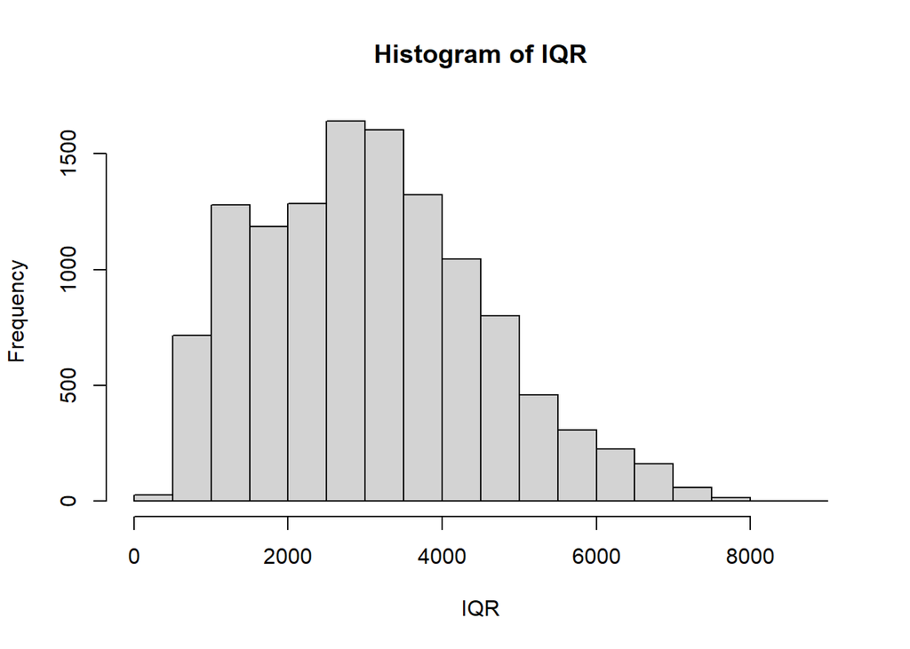

```r
IQR <- voice$IQR
hist(IQR)
```

Then, we calculate the mean and standard deviation of the `IQR` column.

```r
IQR_mean <- mean(IQR)
IQR_sd <- sd(IQR)
```

The `IQR` column is almost normally distributed, we can see that from the histogram and QQ plot below.

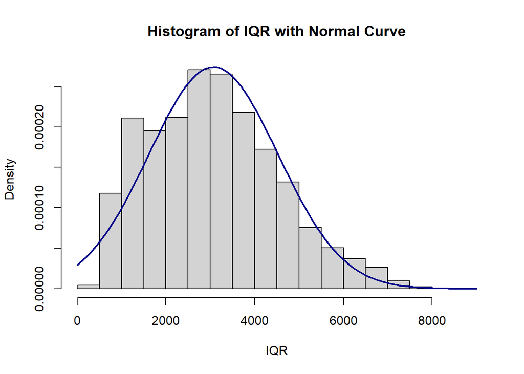

```r
hist(IQR, probability = TRUE, main = "Histogram of IQR with Normal Curve", xlab = "IQR", breaks = 20)
curve(dnorm(x, mean = IQR_mean, sd = IQR_sd), col = "darkblue", lwd = 2, add = TRUE, yaxt = "n")
```

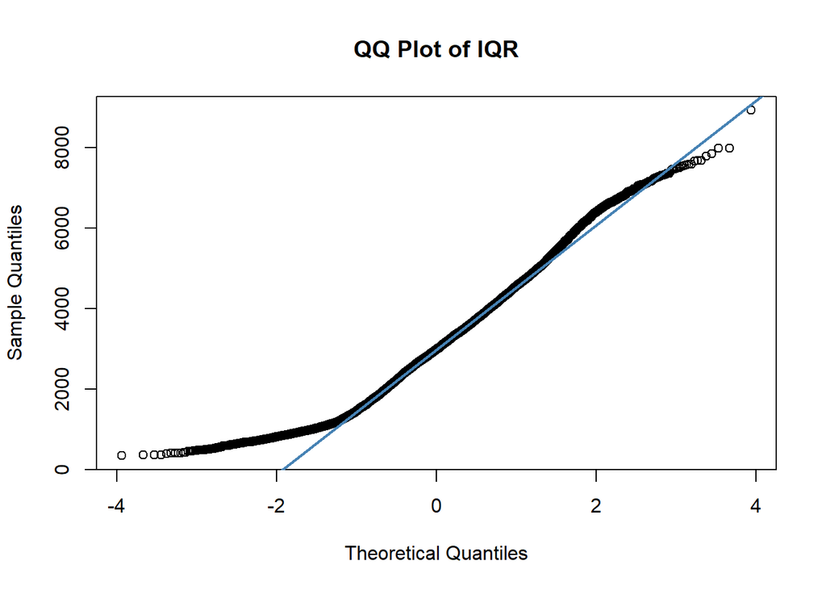

```r
qqnorm(IQR, main = "QQ Plot of IQR")
qqline(IQR, col = "steelblue", lwd = 2)
```

## skew

### Basic Analysis

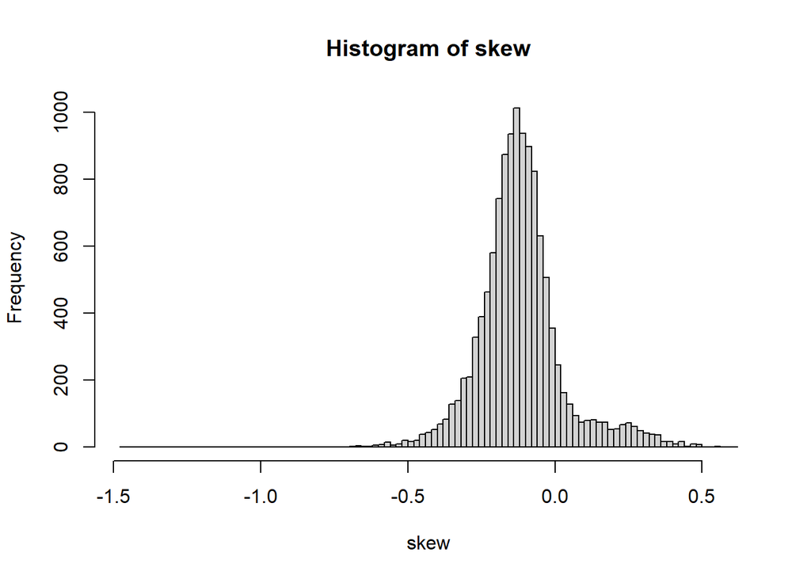

```r
skew <- voice$skew
hist(skew, breaks = 80, main = "Histogram of skew", xlab = "skew")
```

Then, we calculate the mean and standard deviation of the `skew` column.

```r
skew_mean <- mean(skew)
skew_sd <- sd(skew)
```

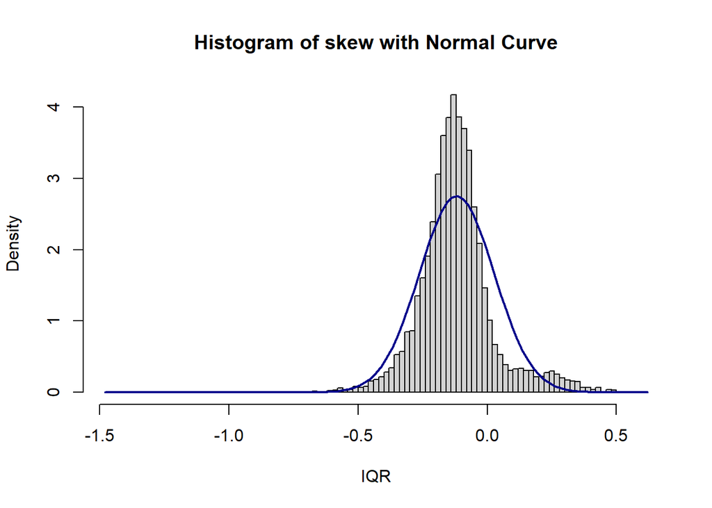

```r
hist(skew, probability = TRUE, main = "Histogram of skew with Normal Curve", xlab = "IQR", breaks = 80)
curve(dnorm(x, mean = skew_mean, sd = skew_sd), col = "darkblue", lwd = 2, add = TRUE, yaxt = "n")
```

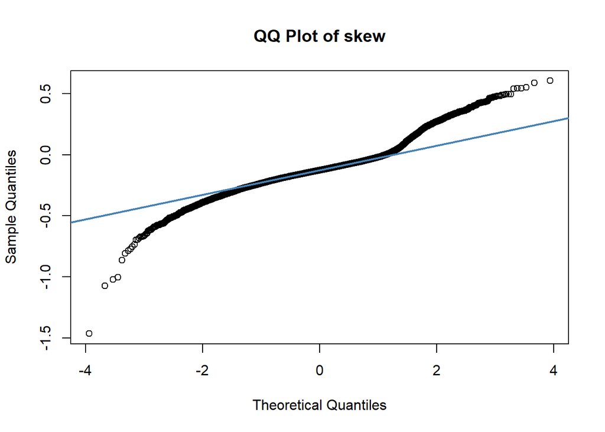

```r
qqnorm(skew, main = "QQ Plot of skew")
qqline(skew, col = "steelblue", lwd = 2)
```

## kurt

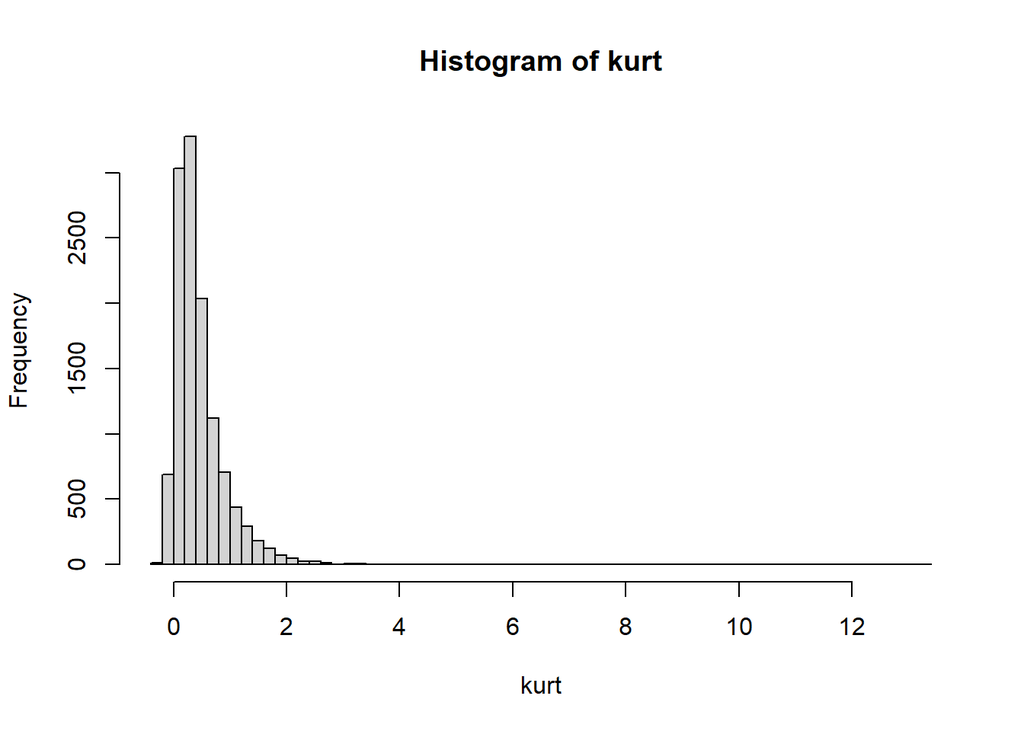

```r
kurt <- voice$kurt
hist(kurt, breaks = 80, main = "Histogram of kurt", xlab = "kurt")
```

Then, we calculate the mean and standard deviation of the `kurt` column.

```r
kurt_mean <- mean(kurt)
kurt_sd <- sd(kurt)
```

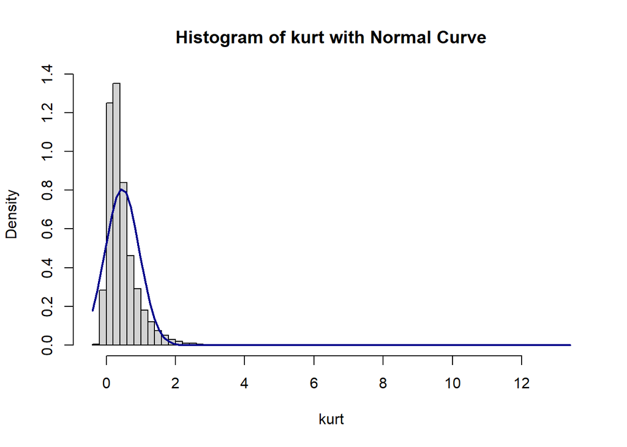

```r
hist(kurt, probability = TRUE, main = "Histogram of kurt with Normal Curve", xlab = "kurt", breaks = 80)
curve(dnorm(x, mean = kurt_mean, sd = kurt_sd), col = "darkblue", lwd = 2, add = TRUE, yaxt = "n")
```

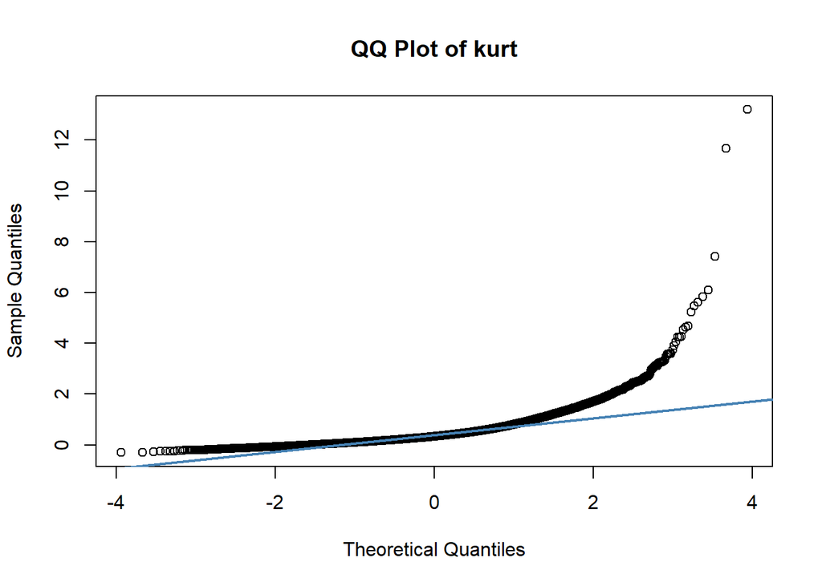

```r
qqnorm(kurt, main = "QQ Plot of kurt")
qqline(kurt, col = "steelblue", lwd = 2)
```

### Log-transformed `kurt`

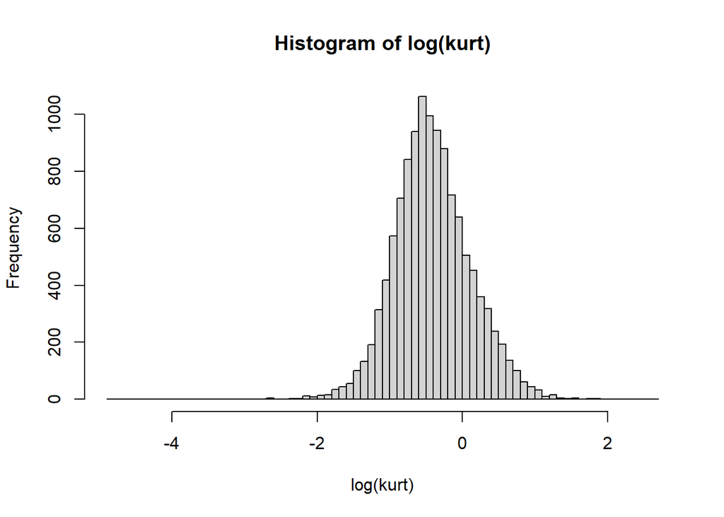

```r
kurt_trans <- log(kurt + 0.31)
hist(kurt_trans, breaks = 80, main = "Histogram of log(kurt)", xlab = "log(kurt)")
```

```r
kurt_trans_mean <- mean(kurt_trans)
kurt_trans_sd <- sd(kurt_trans)
print(paste("Mean of log-transformed kurt:", kurt_trans_mean))
```

```
## [1] "Mean of log-transformed kurt: -0.409042098034566"
```

```r
print(paste("Standard deviation of log-transformed kurt:", kurt_trans_sd))
```

```
## [1] "Standard deviation of log-transformed kurt: 0.527162928424476"
```

#### Histogram with overlaid normal curve

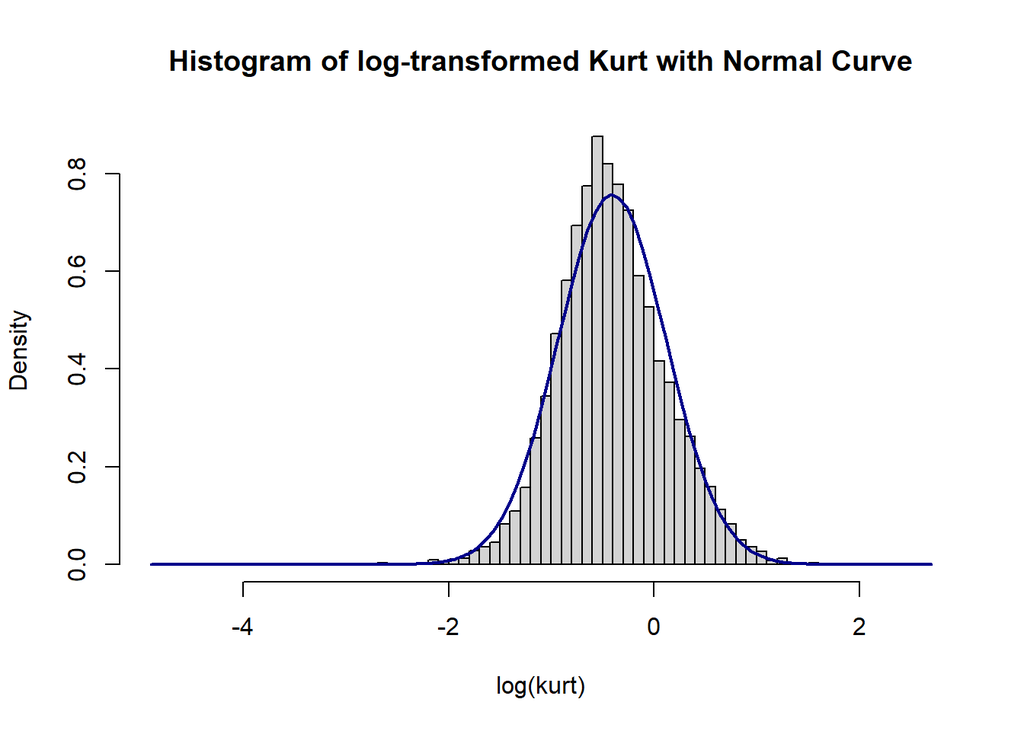

```r
hist(kurt_trans, probability = TRUE, main = "Histogram of log-transformed Kurt with Normal Curve", xlab = "log(kurt)", breaks = 80)
curve(dnorm(x, mean = kurt_trans_mean, sd = kurt_trans_sd), col = "darkblue", lwd = 2, add = TRUE, yaxt = "n")
```

#### QQ plot for log-transformed `kurt`

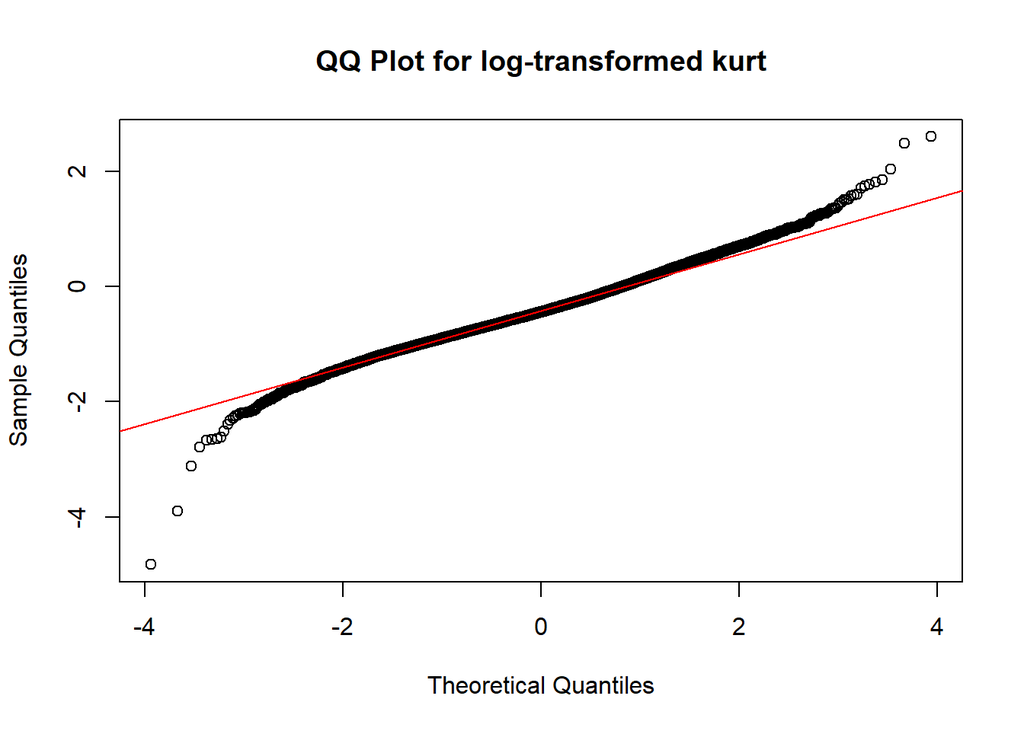

```r
qqnorm(kurt_trans, main = "QQ Plot for log-transformed kurt")
qqline(kurt_trans, col = "red")
```

## sp.ent

### Basic Analysis

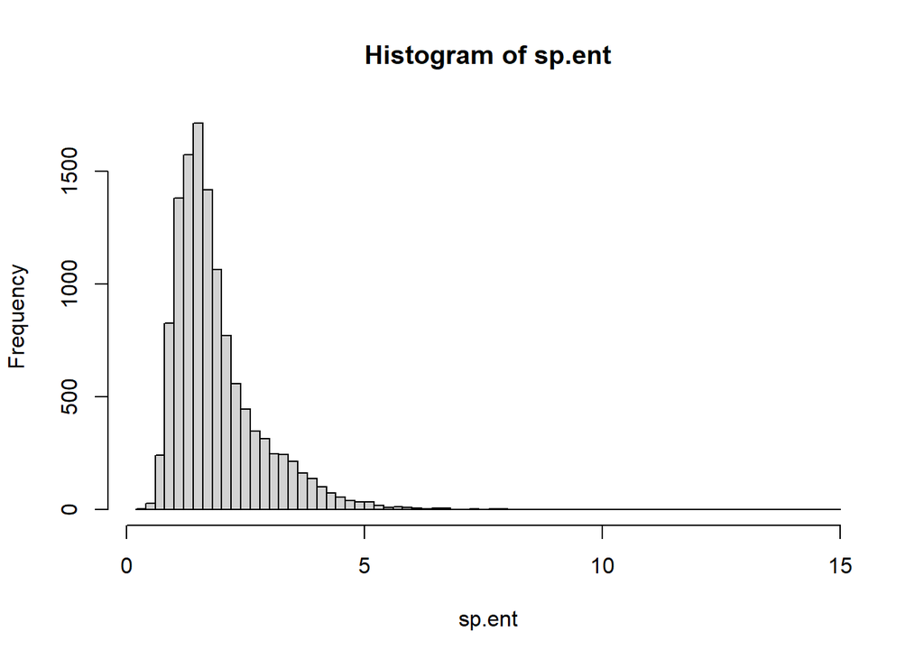

```r
sp_ent <- voice$sp.ent
hist(sp_ent, breaks = 80, main = "Histogram of sp.ent", xlab = "sp.ent")
```

Then, we calculate the mean and standard deviation of the `sp.ent` column.

```r
sp_ent_mean <- mean(sp_ent)
sp_ent_sd <- sd(sp_ent)
print(paste("Mean of sp.ent:", sp_ent_mean))
```

```
## [1] "Mean of sp.ent: 1.89564130104079"
```

```r
print(paste("Standard deviation of sp.ent:", sp_ent_sd))
```

```
## [1] "Standard deviation of sp.ent: 0.948445979428355"
```

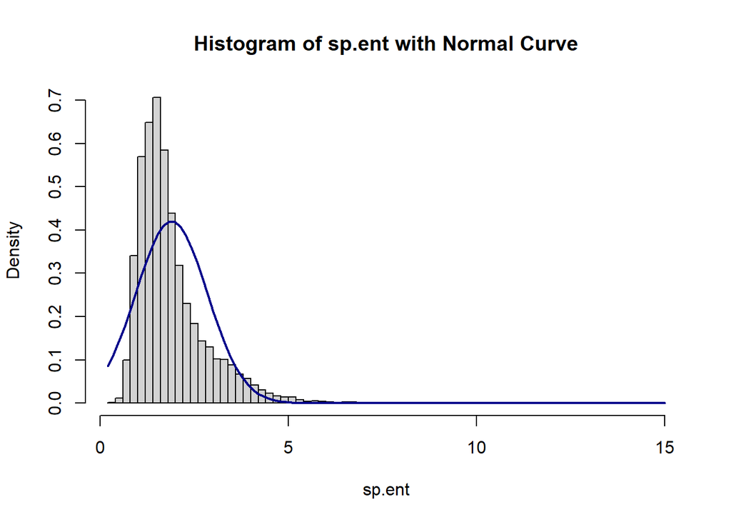

```r
hist(sp_ent, probability = TRUE, main = "Histogram of sp.ent with Normal Curve", xlab = "sp.ent", breaks = 80)
curve(dnorm(x, mean = sp_ent_mean, sd = sp_ent_sd), col = "darkblue", lwd = 2, add = TRUE, yaxt = "n")
```

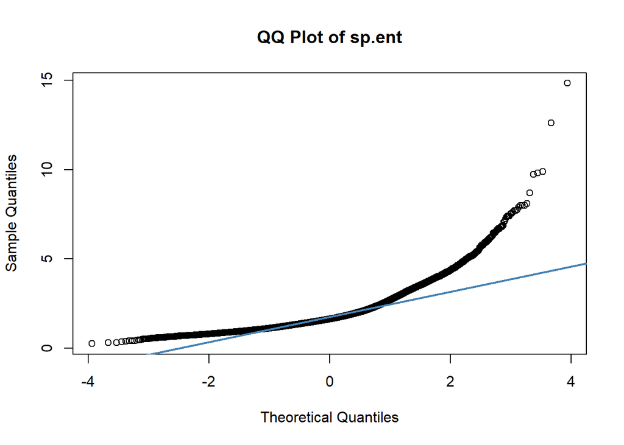

```r
qqnorm(sp_ent, main = "QQ Plot of sp.ent")
qqline(sp_ent, col = "steelblue", lwd = 2)
```

### Log-transformed `sp.ent`

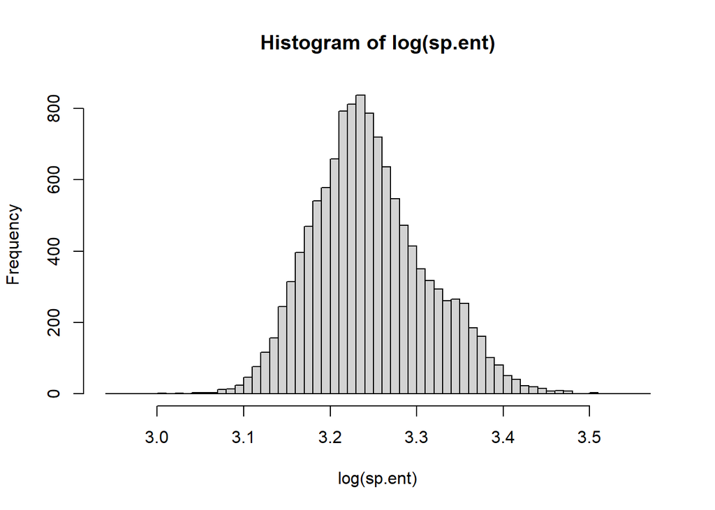

```r
sp_ent_trans <- sqrt(log(sp_ent) + 10)
hist(sp_ent_trans, breaks = 80, main = "Histogram of log(sp.ent)", xlab = "log(sp.ent)")
```

```r
sp_ent_trans_mean <- mean(sp_ent_trans)
sp_ent_trans_sd <- sd(sp_ent_trans)
print(paste("Mean of log-transformed sp.ent:", sp_ent_trans_mean))
```

```
## [1] "Mean of log-transformed sp.ent: 3.24581141189549"
```

```r
print(paste("Standard deviation of log-transformed sp.ent:", sp_ent_trans_sd))
```

```
## [1] "Standard deviation of log-transformed sp.ent: 0.0665096016427285"
```

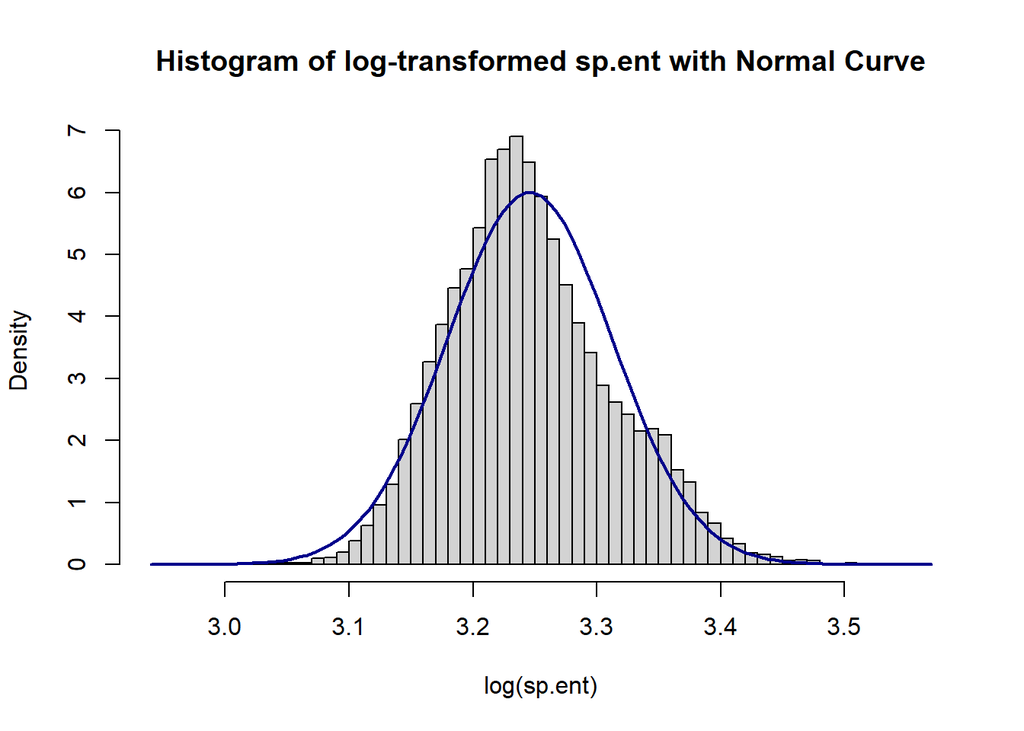

```r
hist(sp_ent_trans, probability = TRUE, main = "Histogram of log-transformed sp.ent with Normal Curve", xlab = "log(sp.ent)", breaks = 80)
curve(dnorm(x, mean = sp_ent_trans_mean, sd = sp_ent_trans_sd), col = "darkblue", lwd = 2, add = TRUE, yaxt = "n")
```

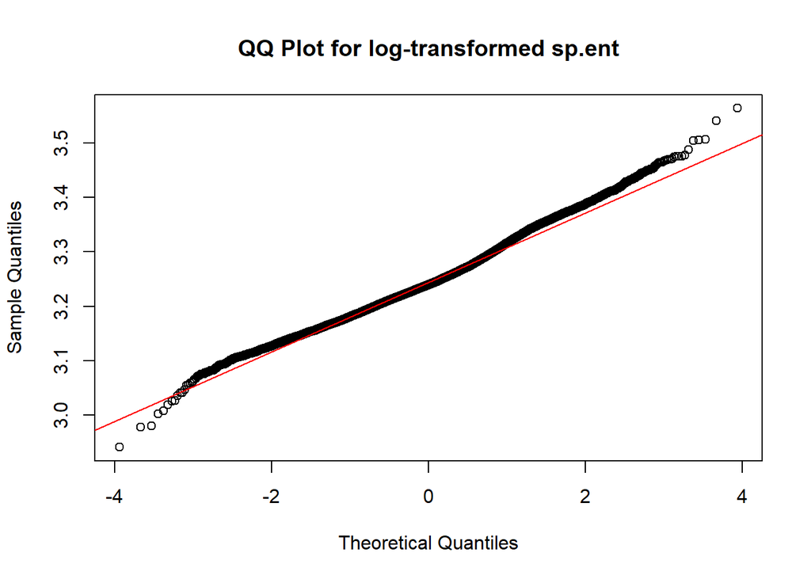

```r
qqnorm(sp_ent_trans, main = "QQ Plot for log-transformed sp.ent")
qqline(sp_ent_trans, col = "red")
```

## sfm

### Basic Analysis

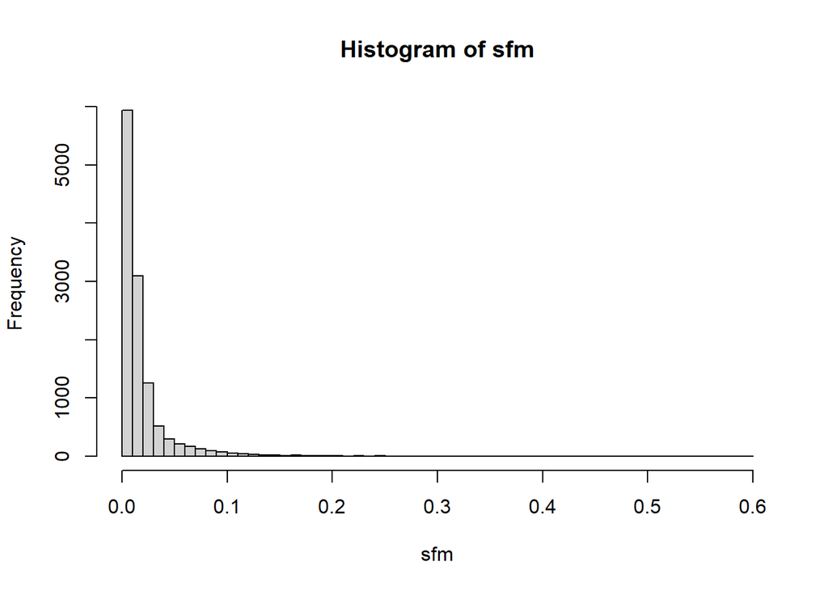

```r
sfm <- voice$sfm
hist(sfm, breaks = 80, main = "Histogram of sfm", xlab = "sfm")
```

Then, we calculate the mean and standard deviation of the `sfm` column.

```r
sfm_mean <- mean(sfm)
sfm_sd <- sd(sfm)
print(paste("Mean of sfm:", sfm_mean))
```

```
## [1] "Mean of sfm: 0.0200547303977314"
```

```r
print(paste("Standard deviation of sfm:", sfm_sd))
```

```
## [1] "Standard deviation of sfm: 0.0333383291477354"
```

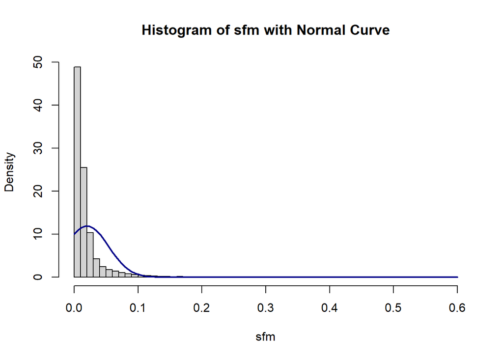

```r
hist(sfm, probability = TRUE, main = "Histogram of sfm with Normal Curve", xlab = "sfm", breaks = 80)
curve(dnorm(x, mean = sfm_mean, sd = sfm_sd), col = "darkblue", lwd = 2, add = TRUE, yaxt = "n")
```

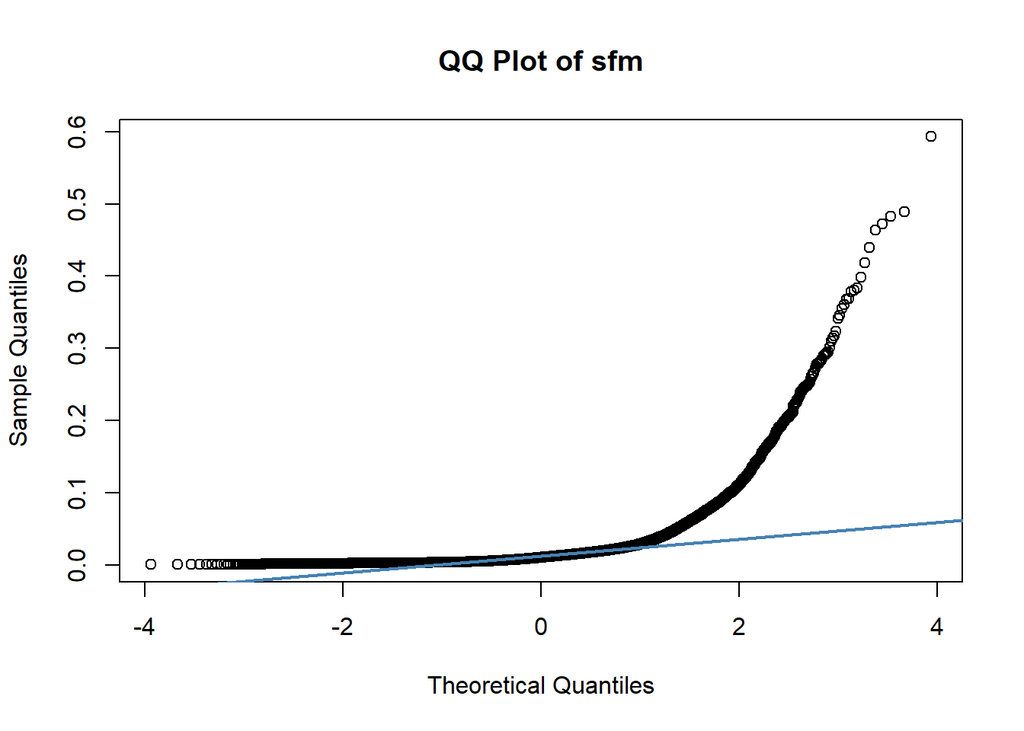

```r
qqnorm(sfm, main = "QQ Plot of sfm")
qqline(sfm, col = "steelblue", lwd = 2)
```

### Log-transformed `sfm`

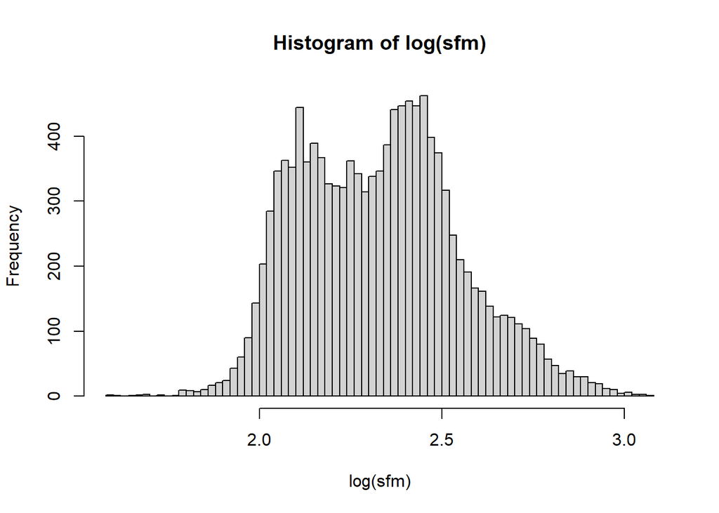

```r
sfm_trans <- sqrt(log(sfm) + 10)
hist(sfm_trans, breaks = 80, main = "Histogram of log(sfm)", xlab = "log(sfm)")
```

```r
sfm_trans_mean <- mean(sfm_trans)
sfm_trans_sd <- sd(sfm_trans)
print(paste("Mean of log-transformed sfm:", sfm_trans_mean))
```

```
## [1] "Mean of log-transformed sfm: 2.32986230002159"
```

```r
print(paste("Standard deviation of log-transformed sfm:", sfm_trans_sd))
```

```
## [1] "Standard deviation of log-transformed sfm: 0.217289569293435"
```

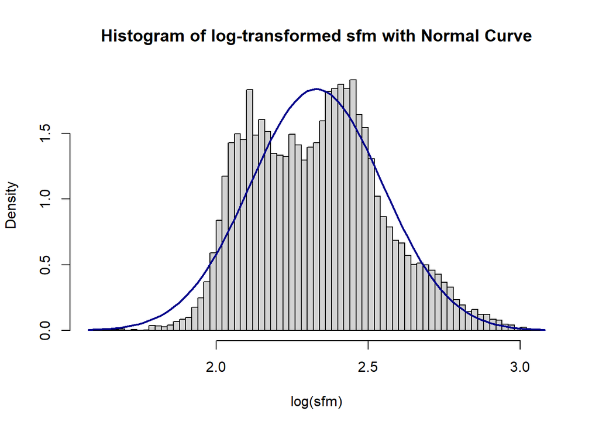

```r
hist(sfm_trans, probability = TRUE, main = "Histogram of log-transformed sfm with Normal Curve", xlab = "log(sfm)", breaks = 80)
curve(dnorm(x, mean = sfm_trans_mean, sd = sfm_trans_sd), col = "darkblue", lwd = 2, add = TRUE, yaxt = "n")
```

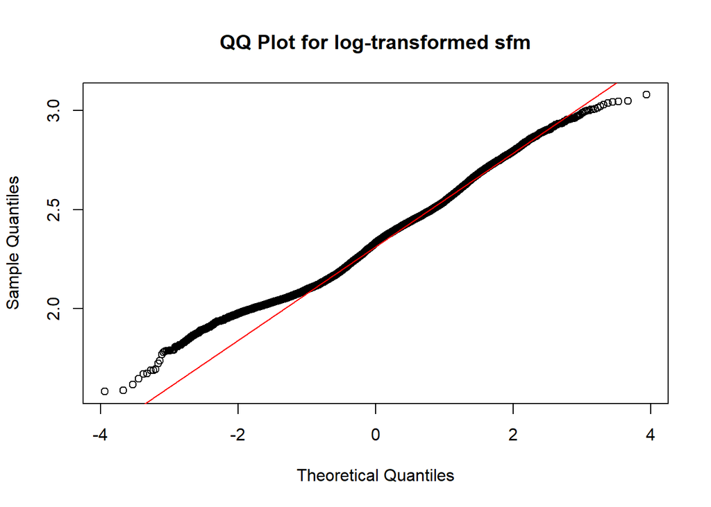

```r
qqnorm(sfm_trans, main = "QQ Plot for log-transformed sfm")
qqline(sfm_trans, col = "red")
```

## mode

### Basic Analysis

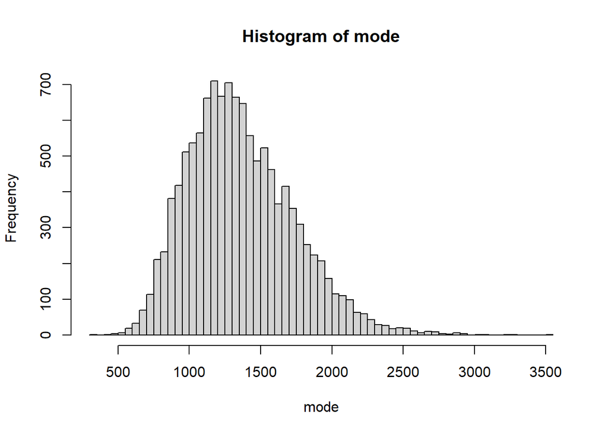

```r
mode <- voice$mode
hist(mode, breaks = 80, main = "Histogram of mode", xlab = "mode")
```

Then, we calculate the mean and standard deviation of the `mode` column.

```r
mode_mean <- mean(mode)
mode_sd <- sd(mode)
print(paste("Mean of mode:", mode_mean))
```

```
## [1] "Mean of mode: 1361.15949796209"
```

```r
print(paste("Standard deviation of mode:", mode_sd))
```

```
## [1] "Standard deviation of mode: 370.71921645733"
```

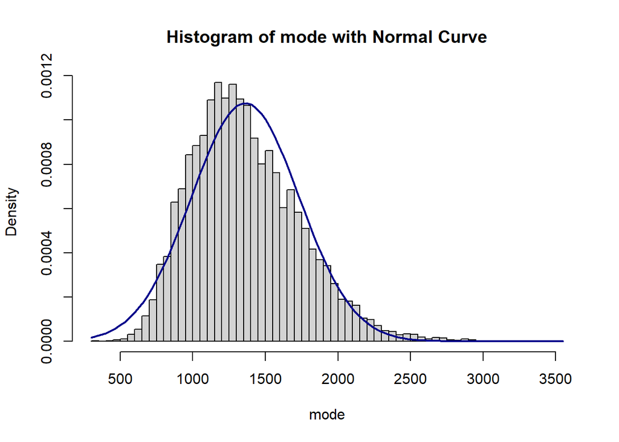

```r
hist(mode, probability = TRUE, main = "Histogram of mode with Normal Curve", xlab = "mode", breaks = 80)
curve(dnorm(x, mean = mode_mean, sd = mode_sd), col = "darkblue", lwd = 2, add = TRUE, yaxt = "n")
```

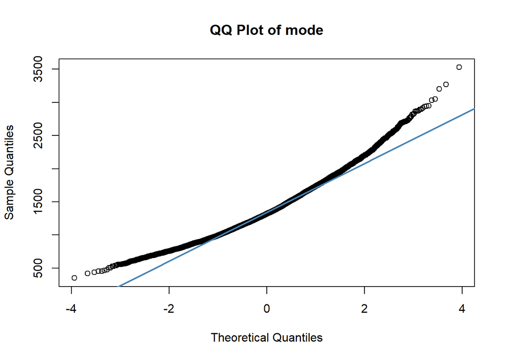

```r
qqnorm(mode, main = "QQ Plot of mode")
qqline(mode, col = "steelblue", lwd = 2)
```

### Log-transformed `mode`

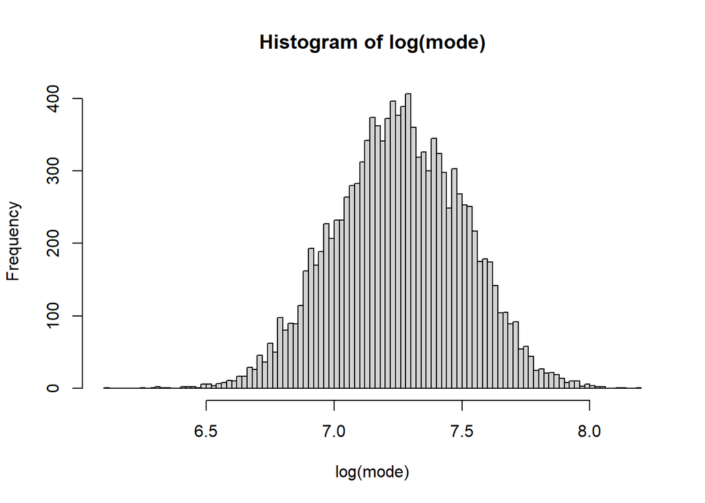

```r
mode_trans <- log(mode + 100)
hist(mode_trans, breaks = 80, main = "Histogram of log(mode)", xlab = "log(mode)")
```

```r
mode_trans_mean <- mean(mode_trans)
mode_trans_sd <- sd(mode_trans)
print(paste("Mean of log-transformed mode:", mode_trans_mean))
```

```
## [1] "Mean of log-transformed mode: 7.2553355596648"
```

```r
print(paste("Standard deviation of log-transformed mode:", mode_trans_sd))
```

```
## [1] "Standard deviation of log-transformed mode: 0.252375165740319"
```

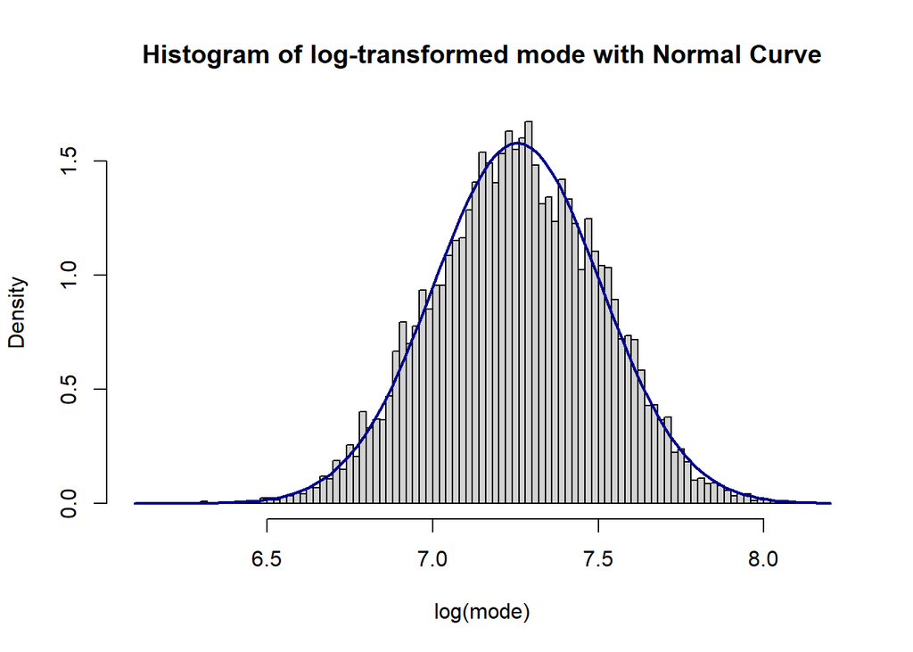

```r
hist(mode_trans, probability = TRUE, main = "Histogram of log-transformed mode with Normal Curve", xlab = "log(mode)", breaks = 80)
curve(dnorm(x, mean = mode_trans_mean, sd = mode_trans_sd), col = "darkblue", lwd = 2, add = TRUE, yaxt = "n")
```

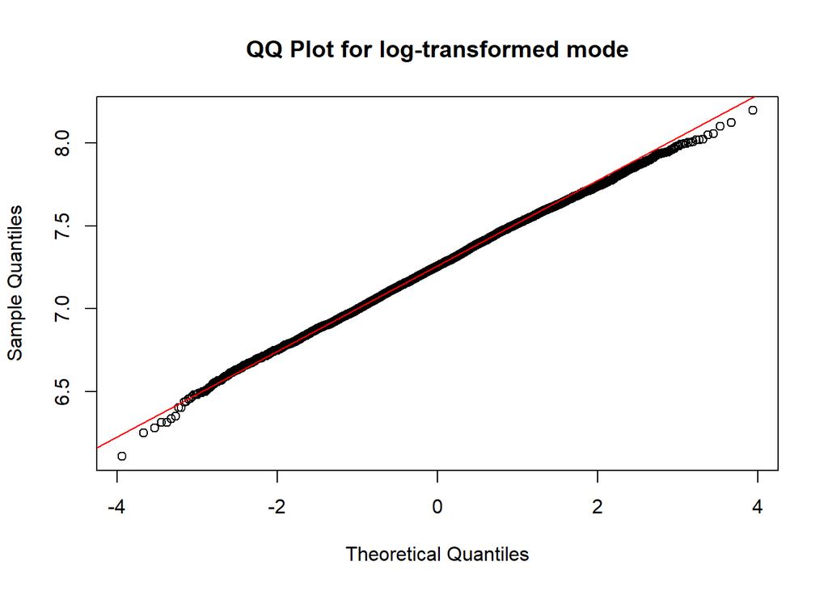

```r
qqnorm(mode_trans, main = "QQ Plot for log-transformed mode")
qqline(mode_trans, col = "red")
```

## Centroid

### Basic Analysis

We firstly load the data and draw a histogram of the `centroid` column.

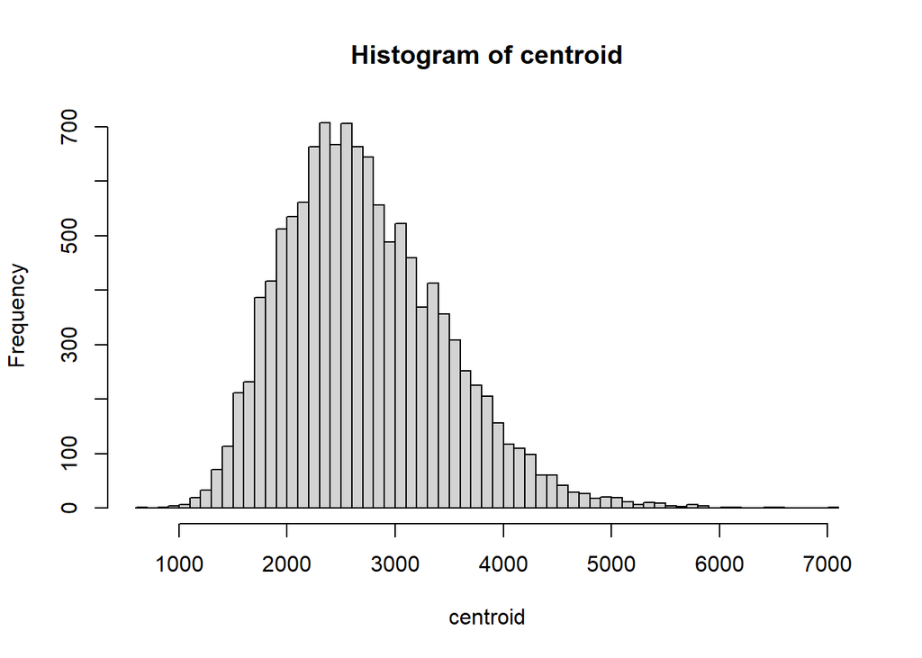

```r
centroid <- voice$centroid
hist(centroid, breaks = 80, main = "Histogram of centroid", xlab = "centroid")
```

Then, we calculate the mean and standard deviation of the `centroid` column.

```r
centroid_mean <- mean(centroid)
centroid_sd <- sd(centroid)
print(paste("Mean of centroid:", centroid_mean))
```

```
## [1] "Mean of centroid: 2721.31899603461"
```

```r
print(paste("Standard deviation of centroid:", centroid_sd))
```

```
## [1] "Standard deviation of centroid: 741.438432305616"
```

#### Histogram with overlaid normal curve

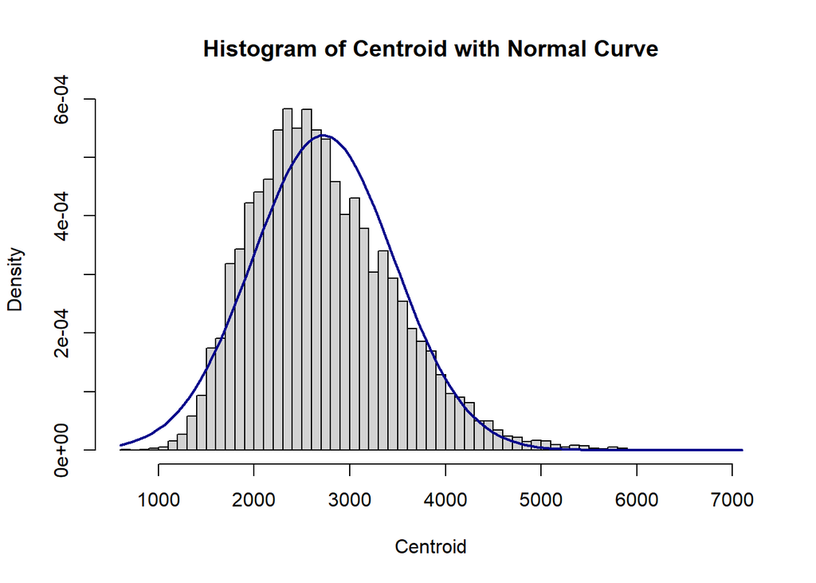

```r
hist(centroid, probability = TRUE, main = "Histogram of Centroid with Normal Curve", xlab = "Centroid", breaks = 80)
curve(dnorm(x, mean = centroid_mean, sd = centroid_sd), col = "darkblue", lwd = 2, add = TRUE, yaxt = "n")
```

#### QQ plot

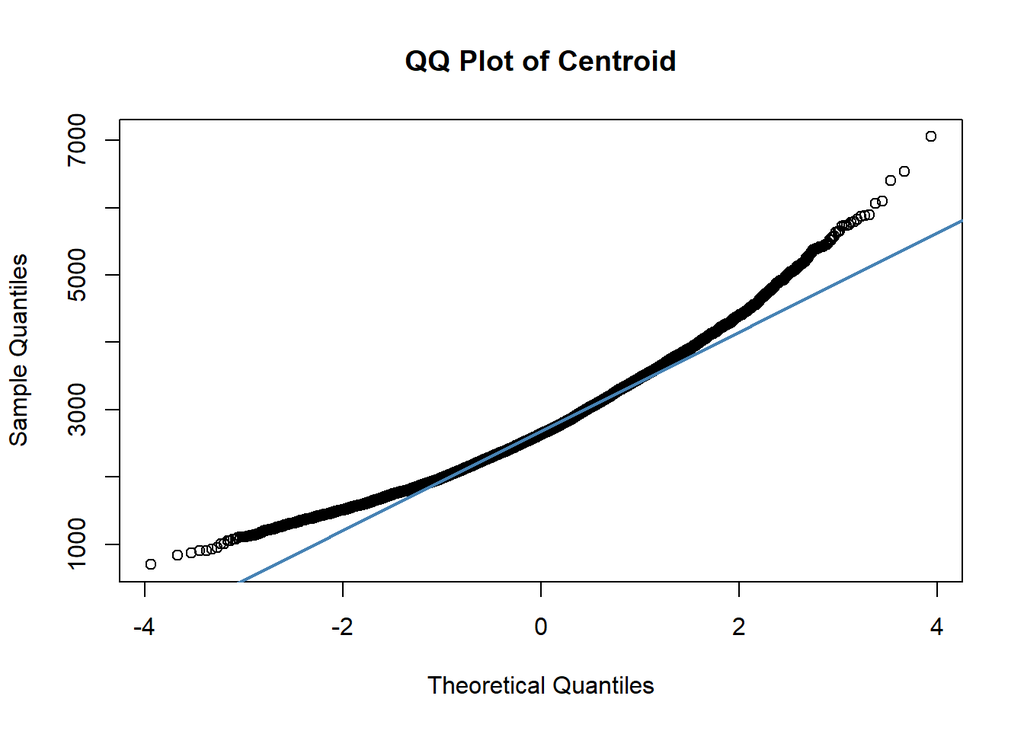

```r
qqnorm(centroid, main = "QQ Plot of Centroid")
qqline(centroid, col = "steelblue", lwd = 2)
```

### Log-transformed `centroid`

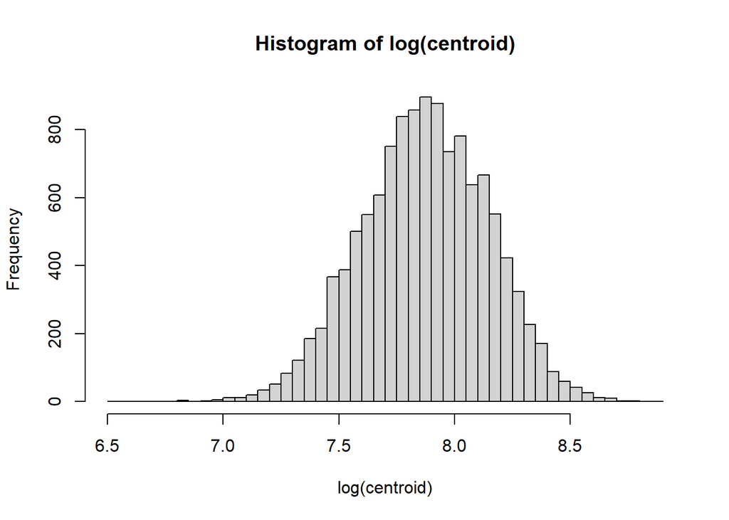

```r
centroid_trans <- log(centroid)
hist(centroid_trans, breaks = 80, main = "Histogram of log(centroid)", xlab = "log(centroid)")
```

```r
centroid_trans_mean <- mean(centroid_trans)
centroid_trans_sd <- sd(centroid_trans)
print(paste("Mean of log-transformed centroid:", centroid_trans_mean))
```

```
## [1] "Mean of log-transformed centroid: 7.87214455103932"
```

```r
print(paste("Standard deviation of log-transformed centroid:", centroid_trans_sd))
```

```
## [1] "Standard deviation of log-transformed centroid: 0.272639109655038"
```

#### Histogram with overlaid normal curve

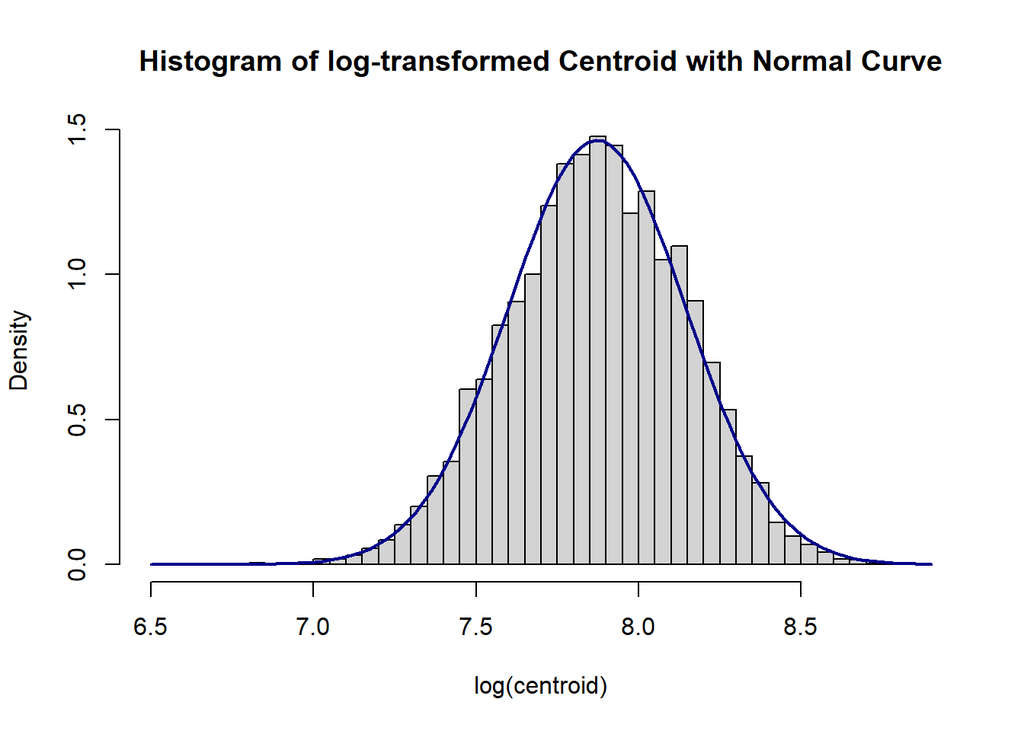

```r
hist(centroid_trans, probability = TRUE, main = "Histogram of log-transformed Centroid with Normal Curve", xlab = "log(centroid)", breaks = 80)
curve(dnorm(x, mean = centroid_trans_mean, sd = centroid_trans_sd), col = "darkblue", lwd = 2, add = TRUE, yaxt = "n")
```

#### QQ plot for log-transformed `centroid`

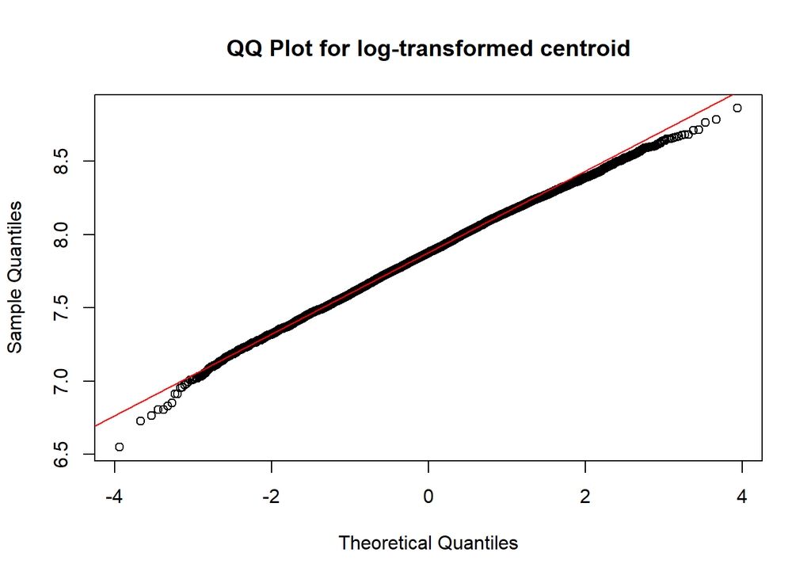

```r
qqnorm(centroid_trans, main = "QQ Plot for log-transformed centroid")
qqline(centroid_trans, col = "red")
```

## MeanFun

### Basic Analysis

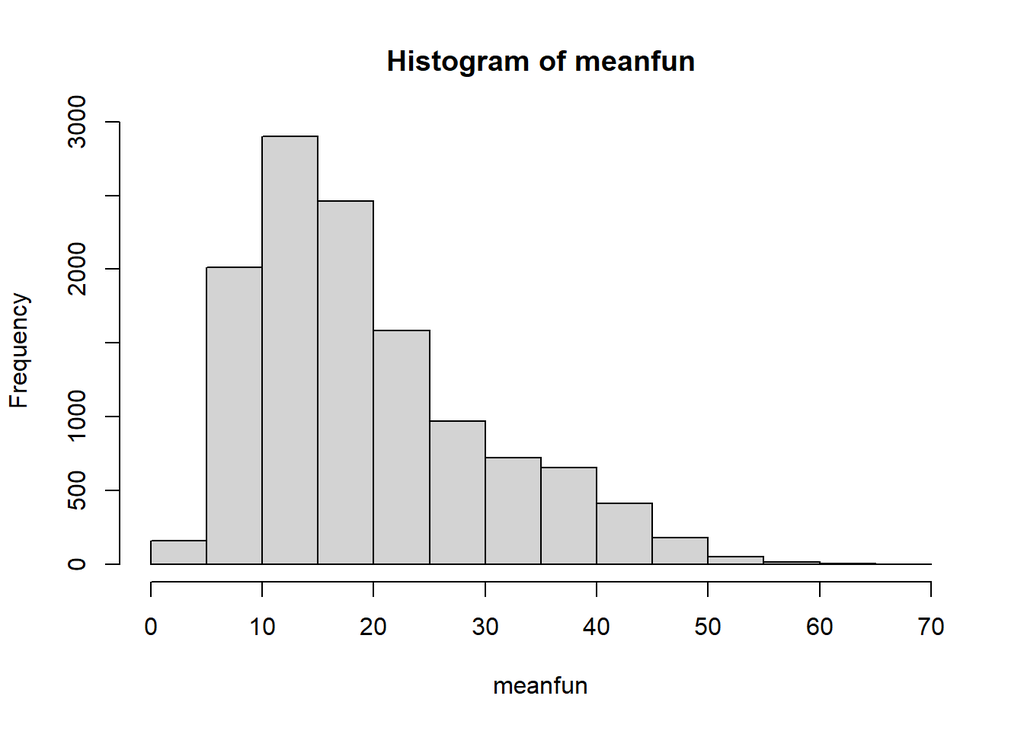

```r
meanfun <- voice$meanfun
hist(meanfun)
```

Then, we calculate the mean and standard deviation of the `meanfun` column.

```r
meanfun_mean <- mean(meanfun)
meanfun_sd <- sd(meanfun)
```

It is very obvious that the `meanfun` column is not normally distributed, we can see that from the histogram and QQ plot below.

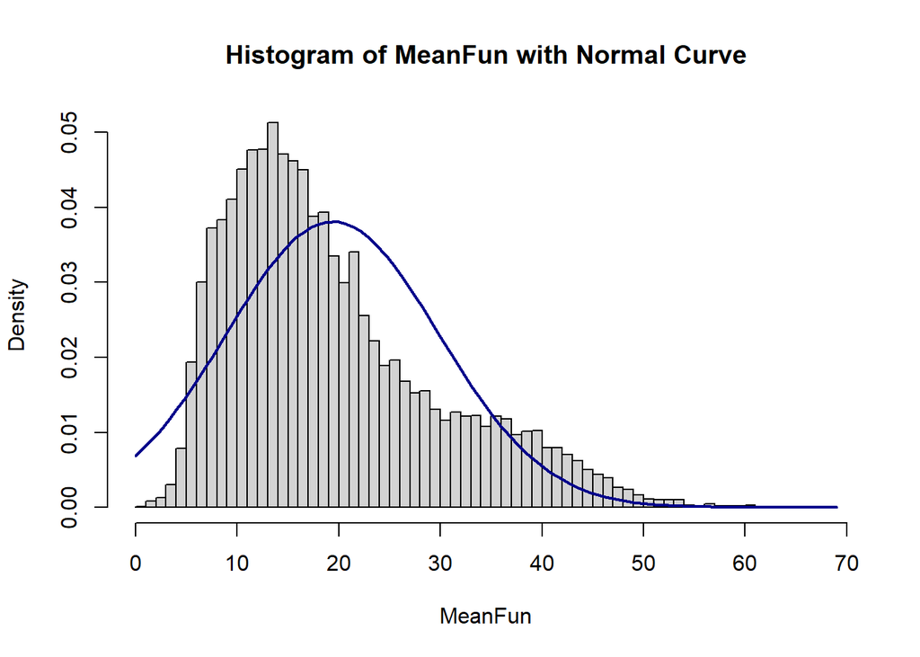

```r
hist(meanfun, probability = TRUE, main = "Histogram of MeanFun with Normal Curve", xlab = "MeanFun", breaks = 80)
curve(dnorm(x, mean = meanfun_mean, sd = meanfun_sd), col = "darkblue", lwd = 2, add = TRUE, yaxt = "n")
```

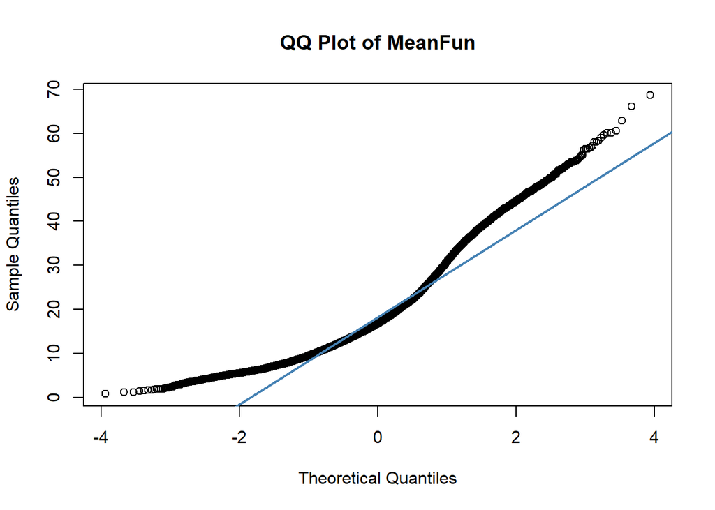

```r
qqnorm(meanfun, main = "QQ Plot of MeanFun")
qqline(meanfun, col = "steelblue", lwd = 2)
```

### Log-transformed `meanfun`

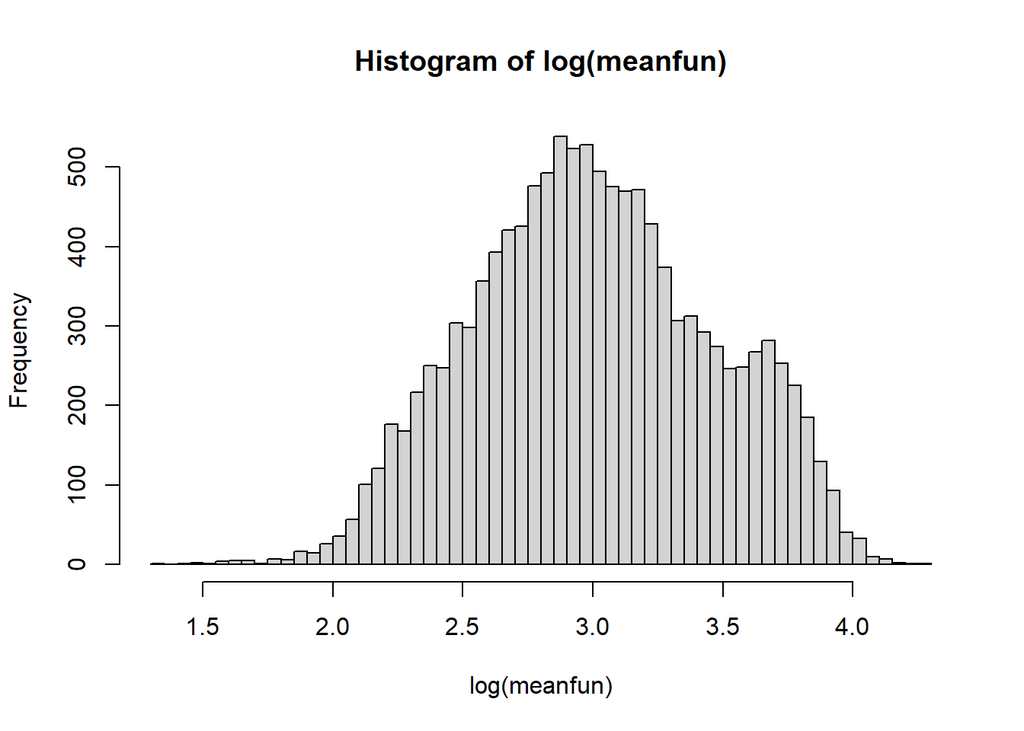

```r
meanfun_trans <- log(meanfun + 3)
hist(meanfun_trans, breaks = 80, main = "Histogram of log(meanfun)", xlab = "log(meanfun)")
```

```r
meanfun_trans_mean <- mean(meanfun_trans)
meanfun_trans_sd <- sd(meanfun_trans)
print(paste("Mean of log-transformed meanfun:", meanfun_trans_mean))
```

```
## [1] "Mean of log-transformed meanfun: 3.00357669730122"
```

```r
print(paste("Standard deviation of log-transformed meanfun:", meanfun_trans_sd))
```

```
## [1] "Standard deviation of log-transformed meanfun: 0.458730809979718"
```

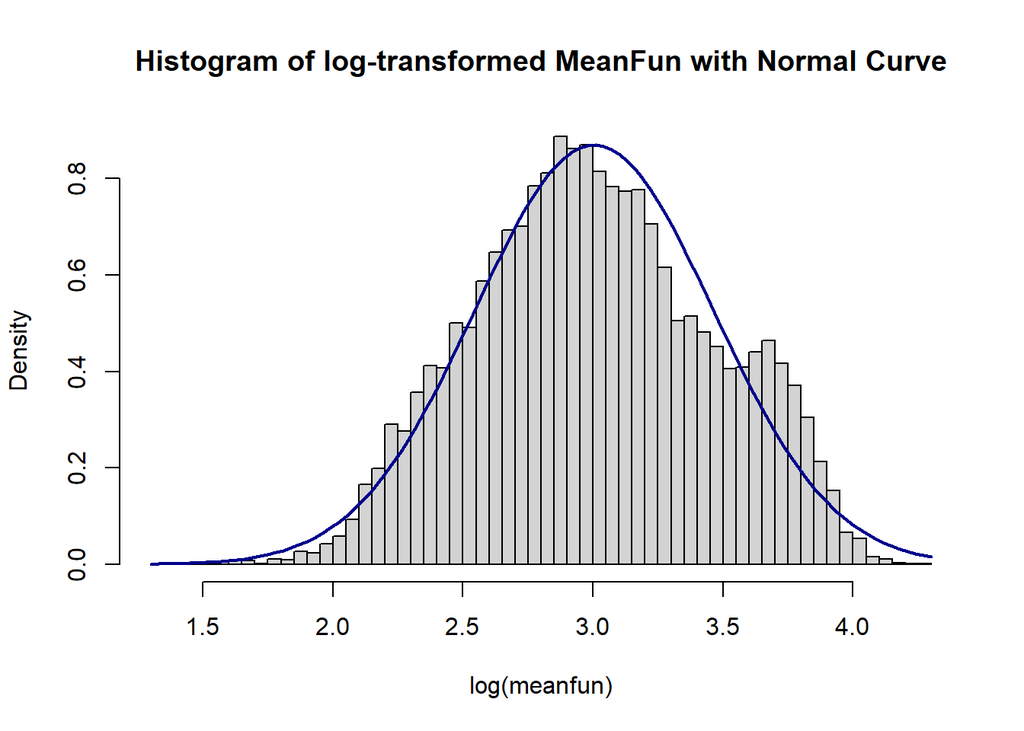

```r
hist(meanfun_trans, probability = TRUE, main = "Histogram of log-transformed MeanFun with Normal Curve", xlab = "log(meanfun)", breaks = 80)
curve(dnorm(x, mean = meanfun_trans_mean, sd = meanfun_trans_sd), col = "darkblue", lwd = 2, add = TRUE, yaxt = "n")
```

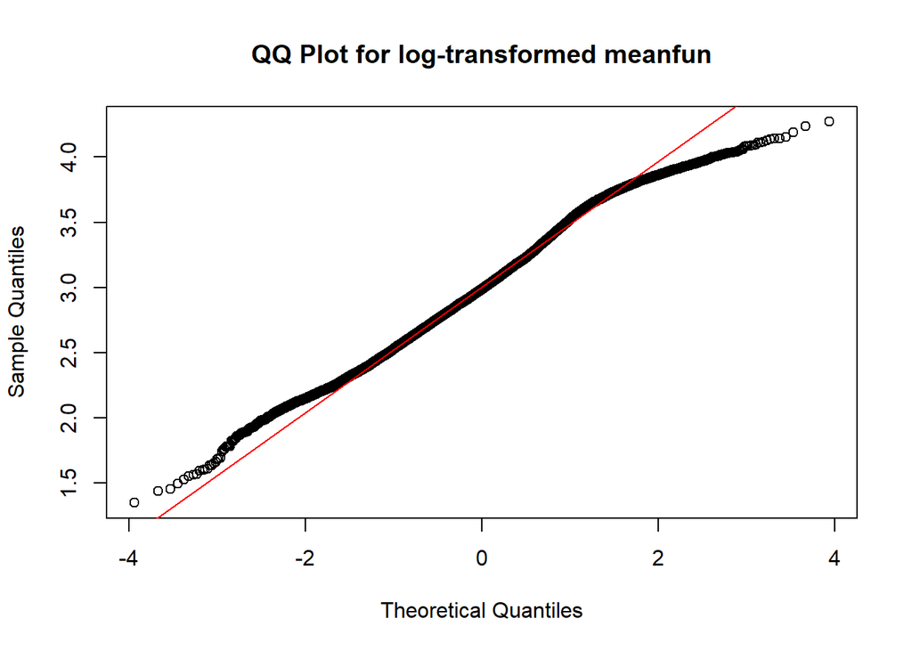

```r
qqnorm(meanfun_trans, main = "QQ Plot for log-transformed meanfun")
qqline(meanfun_trans, col = "red")
```

## MeanDom

### Basic Analysis

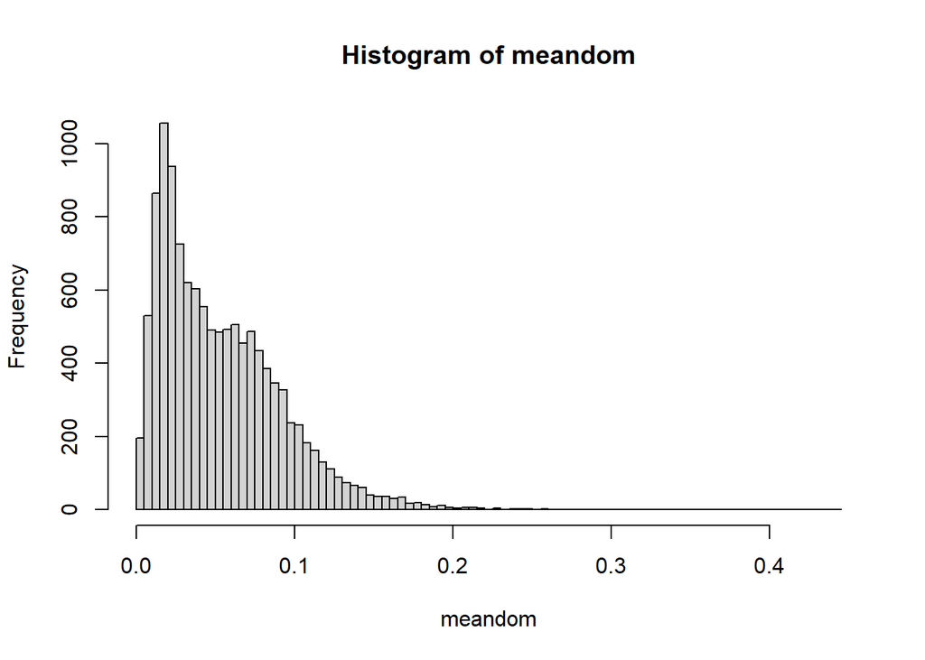

```r
meandom <- voice$meandom
hist(meandom, breaks = 80, main = "Histogram of meandom", xlab = "meandom")
```

Then, we calculate the mean and standard deviation of the `meandom` column.

```r
meandom_mean <- mean(meandom)
meandom_sd <- sd(meandom)
```

We then draw the histogram and QQ plot for the `meandom` column to know more about its distribution.

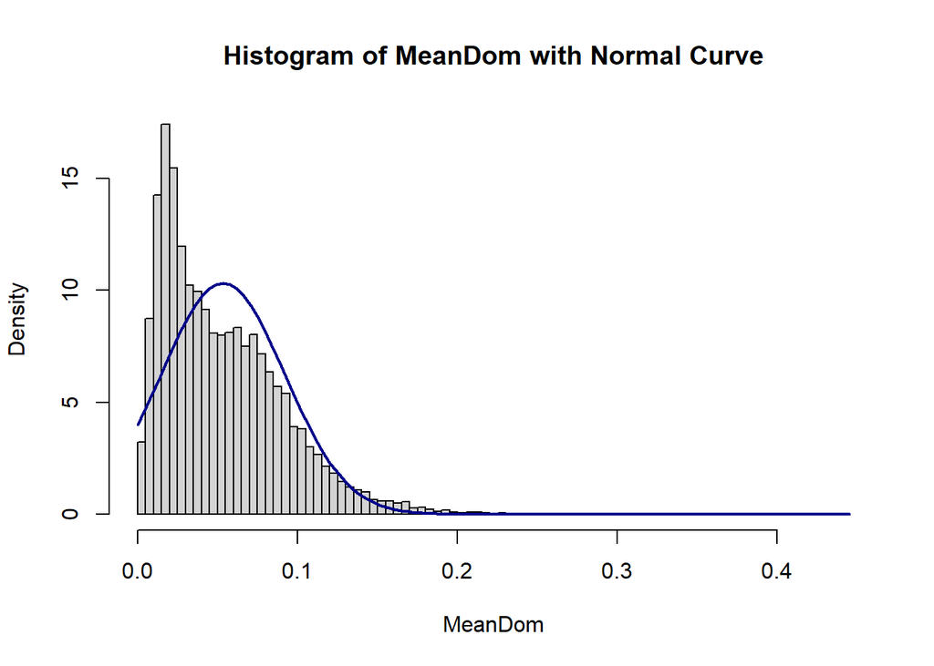

```r
hist(meandom, probability = TRUE, main = "Histogram of MeanDom with Normal Curve", xlab = "MeanDom", breaks = 80)
curve(dnorm(x, mean = meandom_mean, sd = meandom_sd), col = "darkblue", lwd = 2, add = TRUE, yaxt = "n")
```

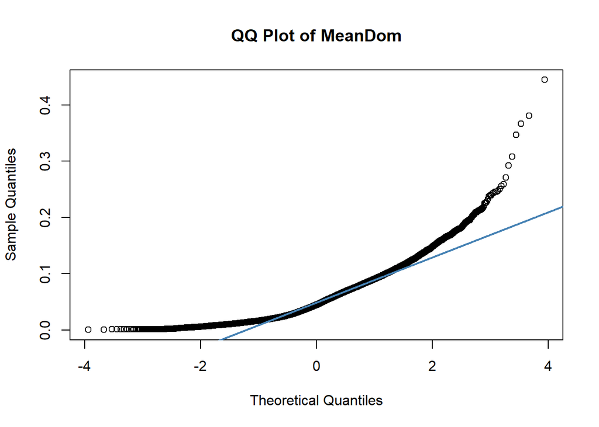

```r
qqnorm(meandom, main = "QQ Plot of MeanDom")
qqline(meandom, col = "steelblue", lwd = 2)
```

### log-transformed `meandom`

After multiple attempts to transform the `meandom` column, we found that the log-transformation with $f(x)=\log(x + 0.01)$ is the best transformation for this column.

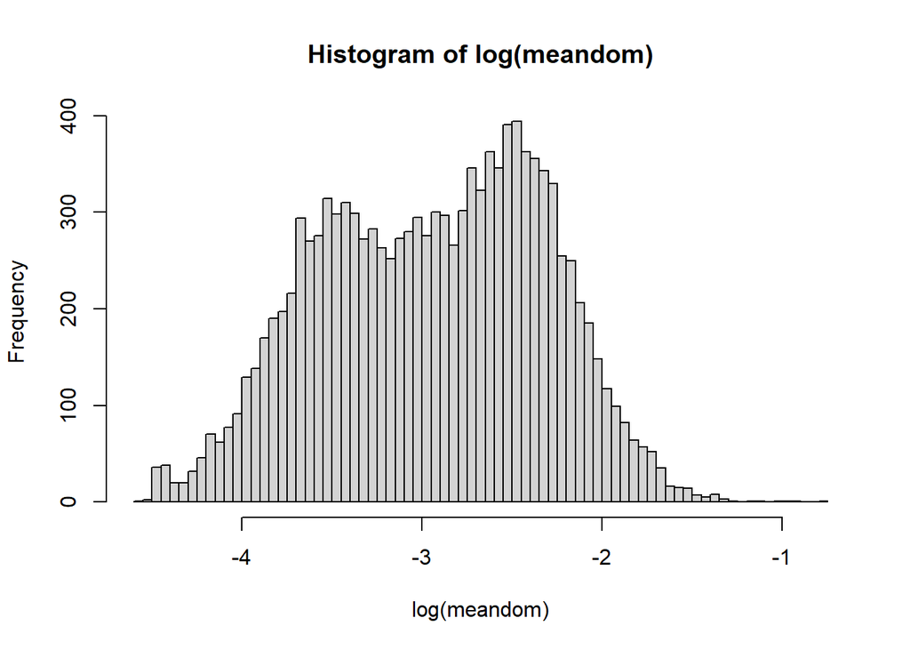

```r
meandom_trans <- log(meandom + 0.01)
hist(meandom_trans, breaks = as.integer(sqrt(length(meandom_trans))), main = "Histogram of log(meandom)", xlab = "log(meandom)")
```

```r
meandom_trans_mean <- mean(meandom_trans)
meandom_trans_sd <- sd(meandom_trans)
print(paste("Mean of log-transformed meandom:", meandom_trans_mean))
```

```
## [1] "Mean of log-transformed meandom: -2.94383343200092"
```

```r
print(paste("Standard deviation of log-transformed meandom:", meandom_trans_sd))
```

```
## [1] "Standard deviation of log-transformed meandom: 0.620535805851869"
```

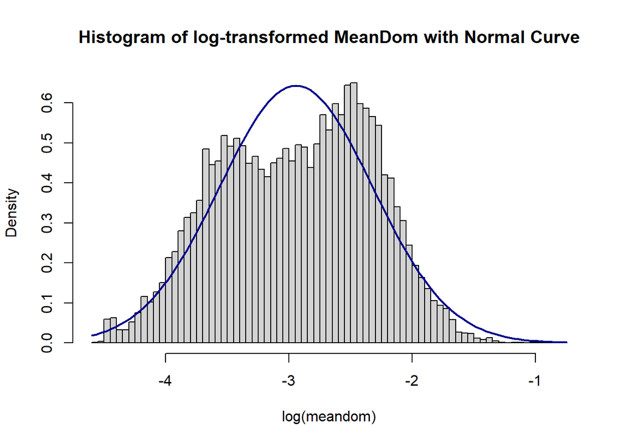

```r
hist(meandom_trans, probability = TRUE, main = "Histogram of log-transformed MeanDom with Normal Curve", xlab = "log(meandom)", breaks = as.integer(sqrt(length(meandom_trans))))
curve(dnorm(x, mean = meandom_trans_mean, sd = meandom_trans_sd), col = "darkblue", lwd = 2, add = TRUE, yaxt = "n")
```

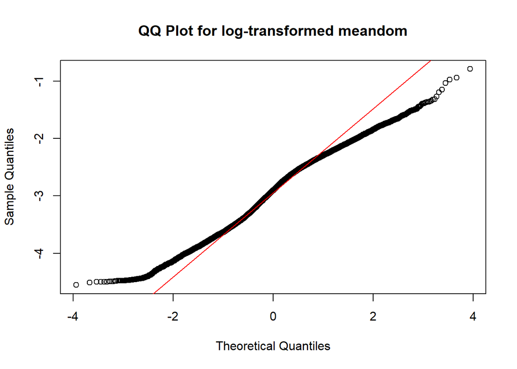

```r
qqnorm(meandom_trans, main = "QQ Plot for log-transformed meandom")
qqline(meandom_trans, col = "red")
```

## MinDom

### Basic Analysis

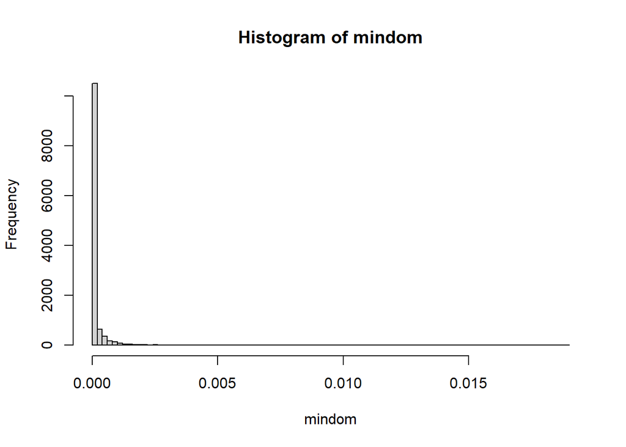

```r
mindom <- voice$mindom
hist(mindom, breaks = 80, main = "Histogram of mindom", xlab = "mindom")
```

Then, we calculate the mean and standard deviation of the `mindom` column.

```r
mindom_mean <- mean(mindom)
mindom_sd <- sd(mindom)
```

We then draw the histogram and QQ plot for the `mindom` column to know more about its distribution.

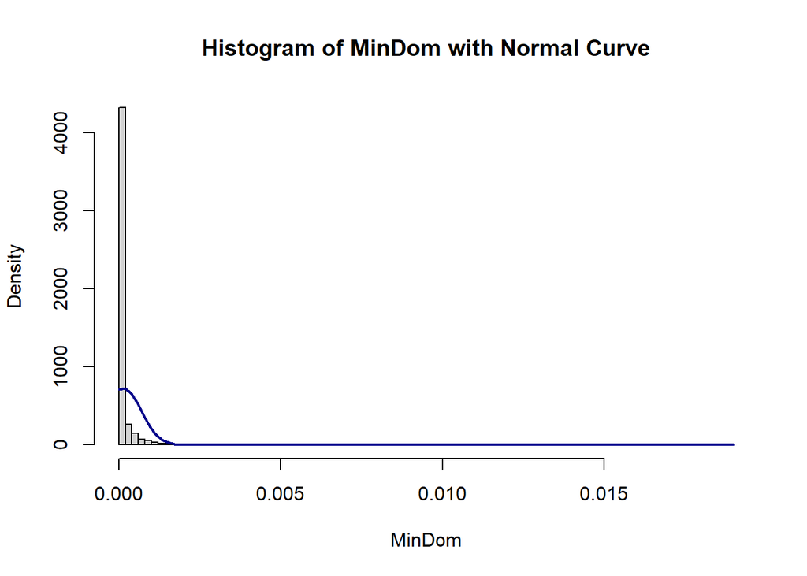

```r
hist(mindom, probability = TRUE, main = "Histogram of MinDom with Normal Curve", xlab = "MinDom", breaks = 80)
curve(dnorm(x, mean = mindom_mean, sd = mindom_sd), col = "darkblue", lwd = 2, add = TRUE, yaxt = "n")
```

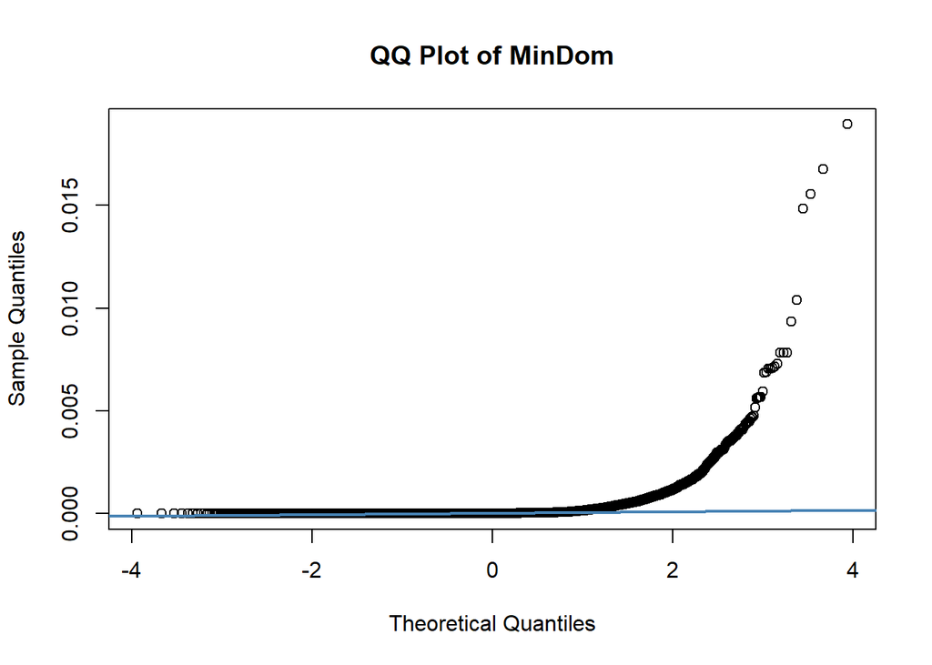

```r
qqnorm(mindom, main = "QQ Plot of MinDom")
qqline(mindom, col = "steelblue", lwd = 2)
```

### log-transformed `mindom`

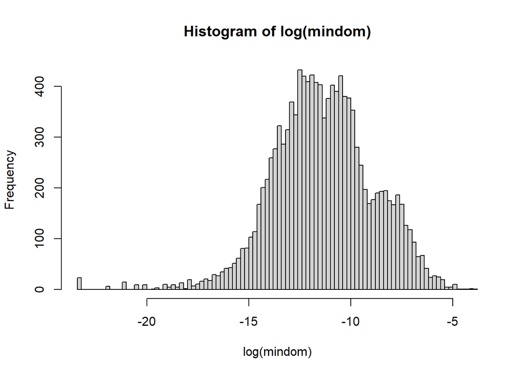

```r
mindom_trans <- log(mindom)
hist(mindom_trans, breaks = as.integer(sqrt(length(mindom_trans))), main = "Histogram of log(mindom)", xlab = "log(mindom)")
```

```r
mindom_trans_mean <- mean(mindom_trans)
mindom_trans_sd <- sd(mindom_trans)
print(paste("Mean of log-transformed mindom:", mindom_trans_mean))
```

```
## [1] "Mean of log-transformed mindom: -11.3730692247243"
```

```r
print(paste("Standard deviation of log-transformed mindom:", mindom_trans_sd))
```

```
## [1] "Standard deviation of log-transformed mindom: 2.45400913865441"
```

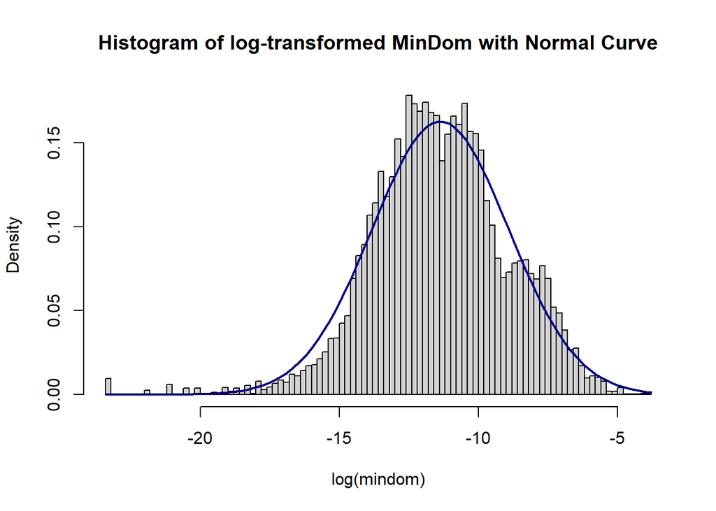

```r
hist(mindom_trans, probability = TRUE, main = "Histogram of log-transformed MinDom with Normal Curve", xlab = "log(mindom)", breaks = as.integer(sqrt(length(mindom_trans))))
curve(dnorm(x, mean = mindom_trans_mean, sd = mindom_trans_sd), col = "darkblue", lwd = 2, add = TRUE, yaxt = "n")
```

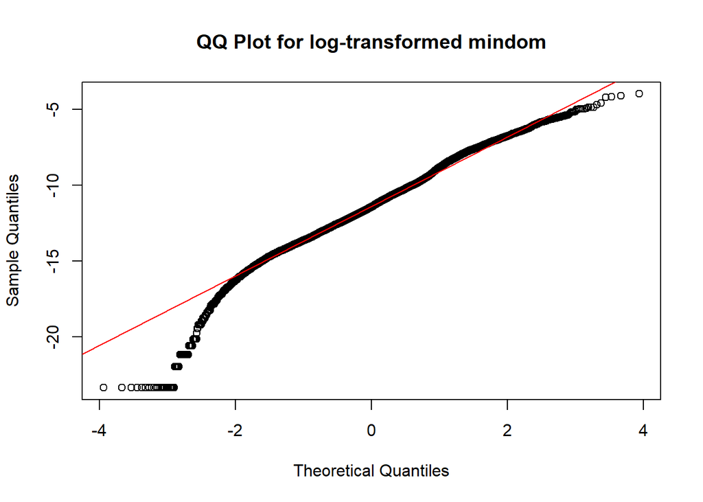

```r
qqnorm(mindom_trans, main = "QQ Plot for log-transformed mindom")
qqline(mindom_trans, col = "red")
```

## MaxDom

### Basic Analysis

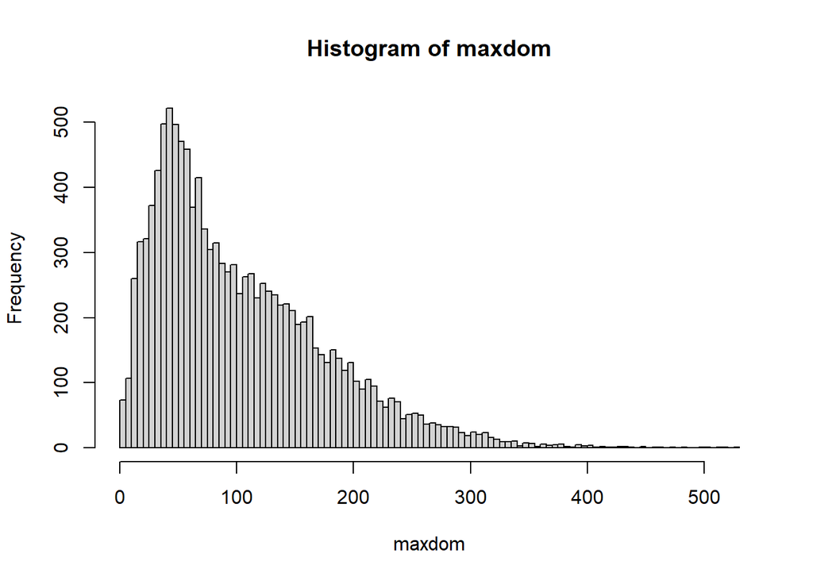

```r
maxdom <- voice$maxdom
hist(maxdom, breaks = 80, main = "Histogram of maxdom", xlab = "maxdom")
```

Then, we calculate the mean and standard deviation of the `maxdom` column.

```r
maxdom_mean <- mean(maxdom)
maxdom_sd <- sd(maxdom)
```

We then draw the histogram and QQ plot for the `maxdom` column to know more about its distribution.

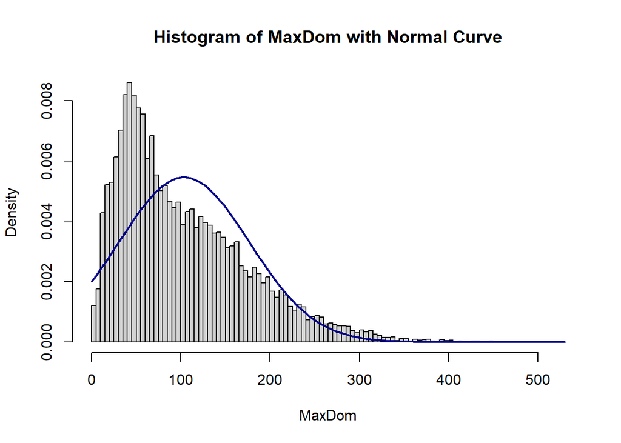

```r
hist(maxdom, probability = TRUE, main = "Histogram of MaxDom with Normal Curve", xlab = "MaxDom", breaks = 80)
curve(dnorm(x, mean = maxdom_mean, sd = maxdom_sd), col = "darkblue", lwd = 2, add = TRUE, yaxt = "n")
```

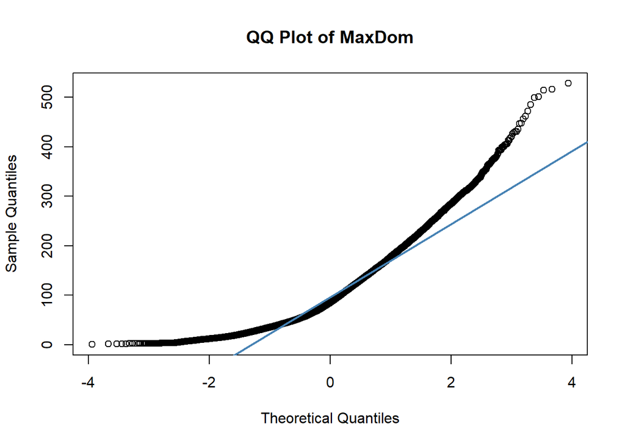

```r
qqnorm(maxdom, main = "QQ Plot of MaxDom")
qqline(maxdom, col = "steelblue", lwd = 2)
```

### Transformed `maxdom`

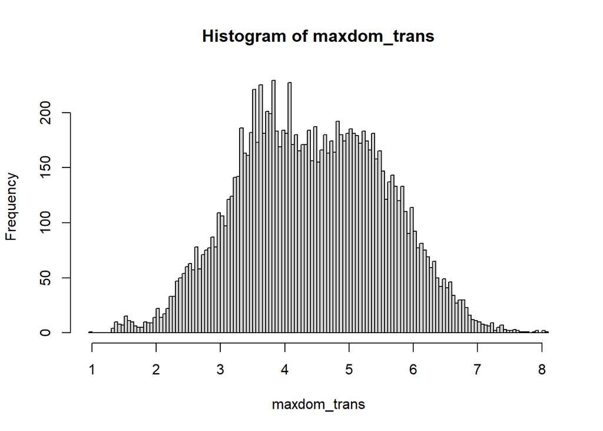

```r
maxdom_trans <- maxdom^(1 / 3)
hist(maxdom_trans, breaks = as.integer(sqrt(length(maxdom_trans))), main = "Histogram of maxdom_trans", xlab = "maxdom_trans")
```

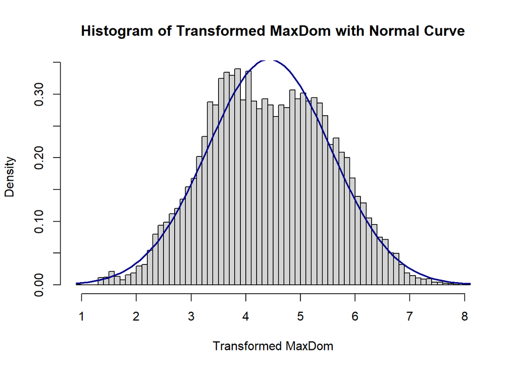

```r
hist(maxdom_trans, probability = TRUE, main = "Histogram of Transformed MaxDom with Normal Curve", xlab = "Transformed MaxDom", breaks = 80)
curve(dnorm(x, mean = mean(maxdom_trans), sd = sd(maxdom_trans)), col = "darkblue", lwd = 2, add = TRUE, yaxt = "n")
```

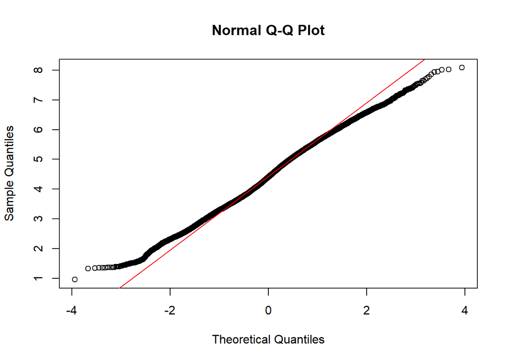

```r
qqnorm(maxdom_trans)
qqline(maxdom_trans, col = "red")
```

## dfrange

### Basic Analysis

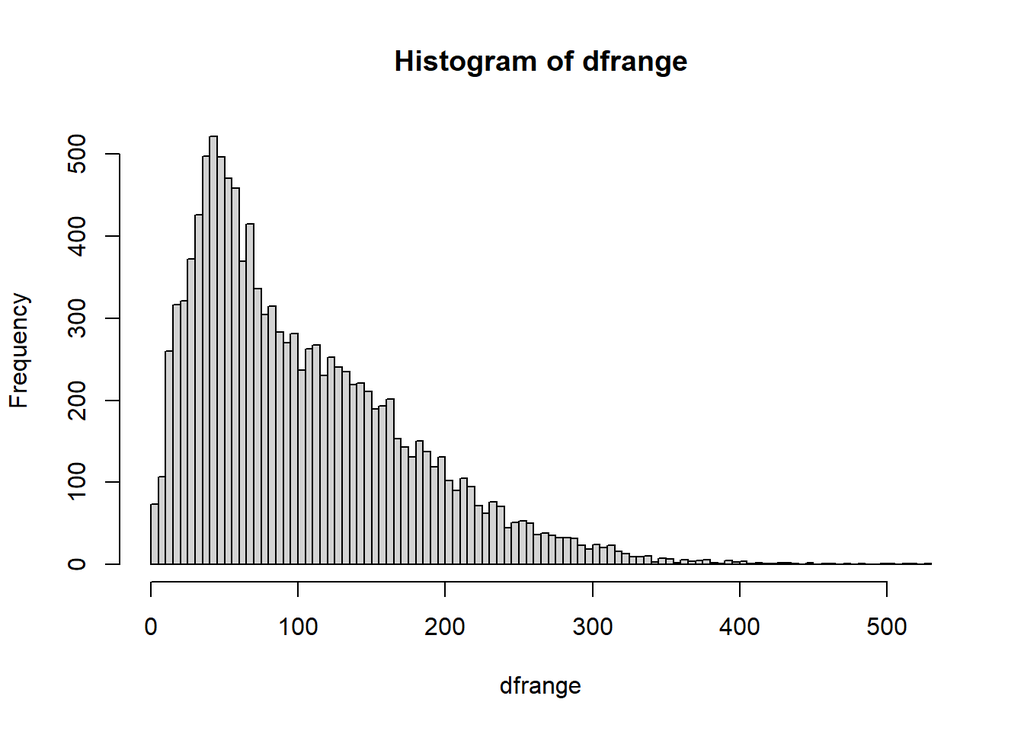

```r
dfrange <- voice$dfrange
hist(dfrange, breaks = 80, main = "Histogram of dfrange", xlab = "dfrange")
```

Then, we calculate the mean and standard deviation of the `dfrange` column.

```r
dfrange_mean <- mean(dfrange)
dfrange_sd <- sd(dfrange)
```

We then draw the histogram and QQ plot for the `dfrange` column to know more about its distribution.

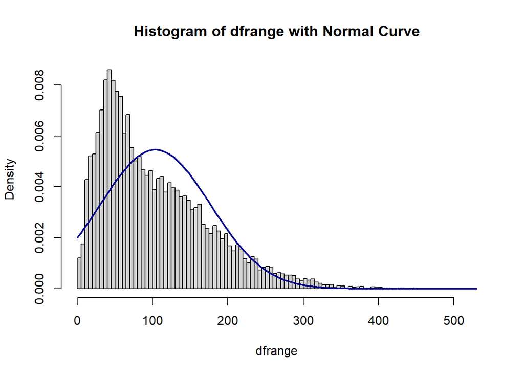

```r
hist(dfrange, probability = TRUE, main = "Histogram of dfrange with Normal Curve", xlab = "dfrange", breaks = 80)
curve(dnorm(x, mean = dfrange_mean, sd = dfrange_sd), col = "darkblue", lwd = 2, add = TRUE, yaxt = "n")
```

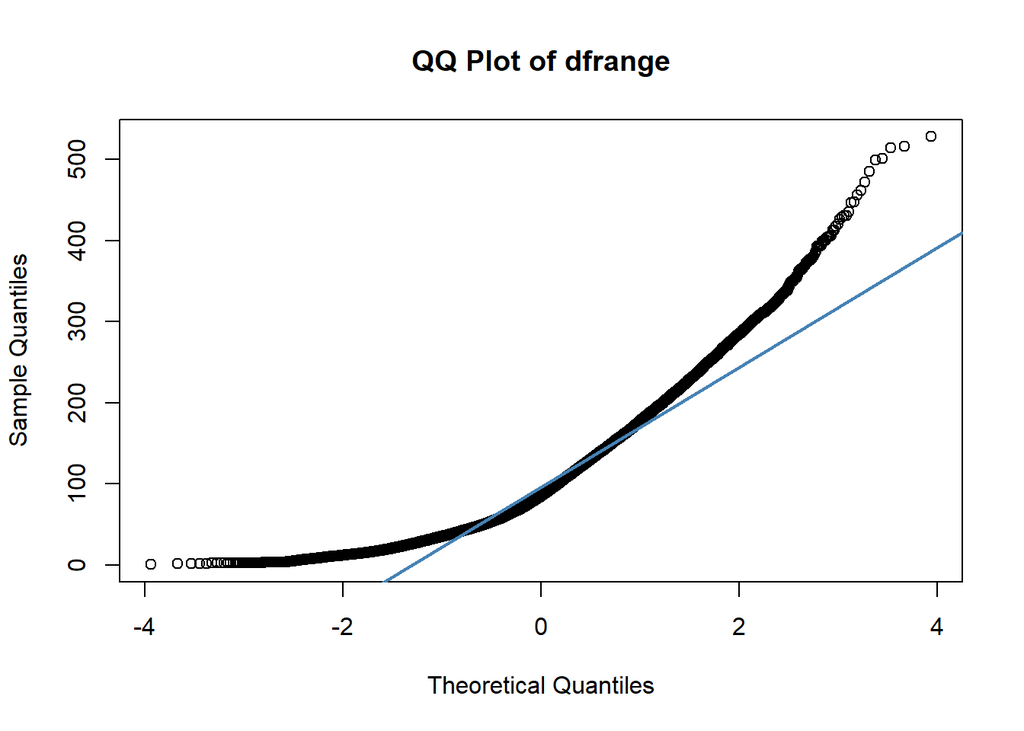

```r
qqnorm(dfrange, main = "QQ Plot of dfrange")
qqline(dfrange, col = "steelblue", lwd = 2)
```